# SMA_finalProject_Rosie_week09

```python
import pandas as pd
import jieba
import jieba.analyse
import re
from wordcloud import WordCloud
import matplotlib.pyplot as plt
import matplotlib.font_manager as fm
# 設定圖的字體大小
plt.rcParams['font.size'] = 14
plt.rcParams['font.sans-serif'] = ['Microsoft JhengHei'] # Windows 中文字體
# plt.rcParams['font.sans-serif'] = ['Noto Sans CJK'] # MacOS 內建中文字體

# plt.rcParams['font.sans-serif']=['SimHei'] #使 matplotilb 中文能正常顯示
fprop = fm.FontProperties(fname="./raw_data/SourceHanSansTW-Regular.otf")

# 設定整份 notebook 圖片的長寬與 dpi
plt.rcParams["figure.figsize"] = [6, 4]
plt.rcParams["figure.dpi"] = 150


# 設定文字雲中文字體路徑
FontPath = 'raw_data/SourceHanSansTW-Regular.otf' # 設定字型

# 讀取資料集
df = pd.read_csv('raw_data/dataset_mbti.csv')
df["artDate"] = pd.to_datetime(df["artDate"])
df['artDate'] = df['artDate'].dt.date

df.head(5)
```

|  | system_id | dataSource | artUrl | artDate | artTitle | artContent | boardID | commentCount | department | gender | school |
| --- | --- | --- | --- | --- | --- | --- | --- | --- | --- | --- | --- |
| 0 | 1 | Dcard | https://www.dcard.tw/f/talk/p/257640963 | 2024-12-31 | 為什麼I人可以用I來當作不社交的藉口 | 如題，MBTI現在很紅，但我很不解有些I人常常碰到需要溝通的事情就說自己是I人，然後就把東西... | talk | 104 | NaN | M | 國立臺灣大學 |
| 1 | 2 | Dcard | https://www.dcard.tw/f/rainbow/p/257627205 | 2024-12-29 | 這麼剛好！ | 我和她的相遇，在盛夏。\n\n而偏偏，這個夏，颱風特別多，所以緣分恰似撞在了颱風眼上， 悄無... | rainbow | 1 | NaN | F | NaN |
| 2 | 3 | Dcard | https://www.dcard.tw/f/mood/p/257619302 | 2024-12-28 | 不回應就是不喜歡 | 雖然知道不管是星座還是MBTI都是參考用，\n但不管過了多久，還是會去翻看有關於你的一切，好... | mood | 3 | NaN | F | NaN |
| 3 | 4 | Dcard | https://www.dcard.tw/f/rainbow/p/257635779 | 2024-12-30 | 不知道姐姐對我有沒有好感 | 12/23在迪卡上認識了一個姐姐\n到今天已經連續聊一個禮拜\n因為我想說慢慢來所以聊的沒有... | rainbow | 0 | NaN | F | NaN |
| 4 | 5 | Dcard | https://www.dcard.tw/f/mood/p/257603606 | 2024-12-26 | 不去要ig就很膽小？？？ | 今天剛好悠閒來測mbti然後，我測試出來的是ENFP，我就把這個測試結果放在ig便利貼裡面，... | mood | 9 | NaN | F | NaN |

```python
clear_df = df.copy()

#去除本次不會用到的欄位
drop_cols = ['system_id', 'dataSource', 'artUrl', 'department', 'school']
clear_df.drop(drop_cols, axis = 1, inplace = True)

#去除文章內容為空值的筆數
clear_df.dropna(subset = ['artContent'], axis=0, how='any', inplace=True)

#新增['sentence']欄位，用'。'取代'\n\n'，並移除'\n'
clear_df['sentence'] = clear_df['artContent'].str.replace(r'\n\n','。', regex=True)
clear_df['sentence'] = clear_df['sentence'].str.replace(r'\n','，', regex=True)

#移除內文中的網址
clear_df['sentence'] = clear_df['sentence'].replace(r'http\S+', '', regex=True).replace(r'www\S+', '', regex=True)

# 移除內文中的表情符號（emoji）
clear_df['sentence'] = clear_df['sentence'].str.replace(r'[\U0001F000-\U0001FFFF]', '', regex=True)
clear_df.head(5)
```

|  | artDate | artTitle | artContent | boardID | commentCount | gender | sentence |
| --- | --- | --- | --- | --- | --- | --- | --- |
| 0 | 2024-12-31 | 為什麼I人可以用I來當作不社交的藉口 | 如題，MBTI現在很紅，但我很不解有些I人常常碰到需要溝通的事情就說自己是I人，然後就把東西... | talk | 104 | M | 如題，MBTI現在很紅，但我很不解有些I人常常碰到需要溝通的事情就說自己是I人，然後就把東西... |
| 1 | 2024-12-29 | 這麼剛好！ | 我和她的相遇，在盛夏。\n\n而偏偏，這個夏，颱風特別多，所以緣分恰似撞在了颱風眼上， 悄無... | rainbow | 1 | F | 我和她的相遇，在盛夏。。而偏偏，這個夏，颱風特別多，所以緣分恰似撞在了颱風眼上， 悄無聲息，... |
| 2 | 2024-12-28 | 不回應就是不喜歡 | 雖然知道不管是星座還是MBTI都是參考用，\n但不管過了多久，還是會去翻看有關於你的一切，好... | mood | 3 | F | 雖然知道不管是星座還是MBTI都是參考用，，但不管過了多久，還是會去翻看有關於你的一切，好想... |
| 3 | 2024-12-30 | 不知道姐姐對我有沒有好感 | 12/23在迪卡上認識了一個姐姐\n到今天已經連續聊一個禮拜\n因為我想說慢慢來所以聊的沒有... | rainbow | 0 | F | 12/23在迪卡上認識了一個姐姐，到今天已經連續聊一個禮拜，因為我想說慢慢來所以聊的沒有很多... |
| 4 | 2024-12-26 | 不去要ig就很膽小？？？ | 今天剛好悠閒來測mbti然後，我測試出來的是ENFP，我就把這個測試結果放在ig便利貼裡面，... | mood | 9 | F | 今天剛好悠閒來測mbti然後，我測試出來的是ENFP，我就把這個測試結果放在ig便利貼裡面，... |

```python
# 資料初步清理
clear_df = df.copy()

# 去除本次不會用到的欄位
drop_cols = ['system_id', 'dataSource', 'artUrl', 'department', 'school']
clear_df.drop(drop_cols, axis=1, inplace=True)

# 去除文章內容為空值的筆數
clear_df.dropna(subset=['artContent'], axis=0, how='any', inplace=True)

# 新增['sentence']欄位，用'。'取代'\n\n'，並移除'\n'
clear_df['sentence'] = clear_df['artContent'].str.replace(r'\n\n','。', regex=True)
clear_df['sentence'] = clear_df['sentence'].str.replace(r'\n','，', regex=True)

# 移除內文中的網址
clear_df['sentence'] = clear_df['sentence'].replace(r'http\S+', '', regex=True).replace(r'www\S+', '', regex=True)

# 移除表情符號（emoji）
clear_df['sentence'] = clear_df['sentence'].str.replace(r'[\U0001F600-\U0001F64F\U0001F300-\U0001F320\U0001F330-\U0001F335\U0001F337-\U0001F37C\U0001F380-\U0001F393\U0001F3A0-\U0001F3C4\U0001F3C6-\U0001F3CA\U0001F3E0-\U0001F3F0\U0001F680-\U0001F6C5\U0001F910-\U0001F93E\U0001F980-\U0001F9E6]', '', regex=True)
clear_df.head(6)
```

|  | artDate | artTitle | artContent | boardID | commentCount | gender | sentence |
| --- | --- | --- | --- | --- | --- | --- | --- |
| 0 | 2024-12-31 | 為什麼I人可以用I來當作不社交的藉口 | 如題，MBTI現在很紅，但我很不解有些I人常常碰到需要溝通的事情就說自己是I人，然後就把東西... | talk | 104 | M | 如題，MBTI現在很紅，但我很不解有些I人常常碰到需要溝通的事情就說自己是I人，然後就把東西... |
| 1 | 2024-12-29 | 這麼剛好！ | 我和她的相遇，在盛夏。\n\n而偏偏，這個夏，颱風特別多，所以緣分恰似撞在了颱風眼上， 悄無... | rainbow | 1 | F | 我和她的相遇，在盛夏。。而偏偏，這個夏，颱風特別多，所以緣分恰似撞在了颱風眼上， 悄無聲息，... |
| 2 | 2024-12-28 | 不回應就是不喜歡 | 雖然知道不管是星座還是MBTI都是參考用，\n但不管過了多久，還是會去翻看有關於你的一切，好... | mood | 3 | F | 雖然知道不管是星座還是MBTI都是參考用，，但不管過了多久，還是會去翻看有關於你的一切，好想... |
| 3 | 2024-12-30 | 不知道姐姐對我有沒有好感 | 12/23在迪卡上認識了一個姐姐\n到今天已經連續聊一個禮拜\n因為我想說慢慢來所以聊的沒有... | rainbow | 0 | F | 12/23在迪卡上認識了一個姐姐，到今天已經連續聊一個禮拜，因為我想說慢慢來所以聊的沒有很多... |
| 4 | 2024-12-26 | 不去要ig就很膽小？？？ | 今天剛好悠閒來測mbti然後，我測試出來的是ENFP，我就把這個測試結果放在ig便利貼裡面，... | mood | 9 | F | 今天剛好悠閒來測mbti然後，我測試出來的是ENFP，我就把這個測試結果放在ig便利貼裡面，... |
| 5 | 2024-12-27 | #資訊 你的 MBTI 是什麼？看看你最適合的職業💪 | 🧠第一個出場的是 INFJ：\n你是 INFJ 嗎？\n這是個只有 1% 的少數人格\n但卻... | job | 6 | M | 第一個出場的是 INFJ：，你是 INFJ 嗎？，這是個只有 1% 的少數人格，但卻在職場上... |

```python
### 斷句, 中文主要以標點符號進行斷句，並清除空的字串
clear_df['sentence'] = clear_df['sentence'].str.split("[,，。！!？?]{1,}")
sent_df = clear_df.explode('sentence').reset_index(drop=True)
sent_df.head(5)
```

|  | artDate | artTitle | artContent | boardID | commentCount | gender | sentence |
| --- | --- | --- | --- | --- | --- | --- | --- |
| 0 | 2024-12-31 | 為什麼I人可以用I來當作不社交的藉口 | 如題，MBTI現在很紅，但我很不解有些I人常常碰到需要溝通的事情就說自己是I人，然後就把東西... | talk | 104 | M | 如題 |
| 1 | 2024-12-31 | 為什麼I人可以用I來當作不社交的藉口 | 如題，MBTI現在很紅，但我很不解有些I人常常碰到需要溝通的事情就說自己是I人，然後就把東西... | talk | 104 | M | MBTI現在很紅 |
| 2 | 2024-12-31 | 為什麼I人可以用I來當作不社交的藉口 | 如題，MBTI現在很紅，但我很不解有些I人常常碰到需要溝通的事情就說自己是I人，然後就把東西... | talk | 104 | M | 但我很不解有些I人常常碰到需要溝通的事情就說自己是I人 |
| 3 | 2024-12-31 | 為什麼I人可以用I來當作不社交的藉口 | 如題，MBTI現在很紅，但我很不解有些I人常常碰到需要溝通的事情就說自己是I人，然後就把東西... | talk | 104 | M | 然後就把東西丟給其他人去處理的這種心態 |
| 4 | 2024-12-31 | 為什麼I人可以用I來當作不社交的藉口 | 如題，MBTI現在很紅，但我很不解有些I人常常碰到需要溝通的事情就說自己是I人，然後就把東西... | talk | 104 | M | 我自己也是I人 |

```python
# 斷詞前先將標點符號清除，並清除空字串
# 去除句子中除了字母、數字、空白字符以外的符號
sent_df['sentence'] = sent_df['sentence'].str.replace(r'[^\w\s]+', '', regex=True).astype(str)

# 把長度小於1的sentence刪掉
sent_df = sent_df[sent_df["sentence"].str.len() > 1]

# 使用jieba進行斷詞
jieba.set_dictionary('dict/dict.txt')

# 參數形式手動將字詞加入斷詞字典
words = ['E人','I人']
for w in words:
    jieba.add_word(w, freq=None, tag=None)

word_df = sent_df.assign(word = sent_df['sentence'].apply(jieba.lcut)).explode('word').drop(['sentence'], axis=1)

# 去除空值
word_df = word_df.dropna(subset=['word'])

#去除少於兩個字的詞語
word_df = word_df.loc[word_df['word'].str.len() > 1]
word_df.head(5)
```

```
Building prefix dict from c:\Users\Rosie\Documents\研究所\社群媒體分析\SMA_finalProject\dict\dict.txt ...
Loading model from cache C:\Users\Rosie\AppData\Local\Temp\jieba.u92e39d8ec94998a9c0e9f5d4cd1e9db0.cache
Loading model cost 0.213 seconds.
Prefix dict has been built successfully.
```

|  | artDate | artTitle | artContent | boardID | commentCount | gender | word |
| --- | --- | --- | --- | --- | --- | --- | --- |
| 0 | 2024-12-31 | 為什麼I人可以用I來當作不社交的藉口 | 如題，MBTI現在很紅，但我很不解有些I人常常碰到需要溝通的事情就說自己是I人，然後就把東西... | talk | 104 | M | 如題 |
| 1 | 2024-12-31 | 為什麼I人可以用I來當作不社交的藉口 | 如題，MBTI現在很紅，但我很不解有些I人常常碰到需要溝通的事情就說自己是I人，然後就把東西... | talk | 104 | M | MBTI |
| 1 | 2024-12-31 | 為什麼I人可以用I來當作不社交的藉口 | 如題，MBTI現在很紅，但我很不解有些I人常常碰到需要溝通的事情就說自己是I人，然後就把東西... | talk | 104 | M | 現在 |
| 1 | 2024-12-31 | 為什麼I人可以用I來當作不社交的藉口 | 如題，MBTI現在很紅，但我很不解有些I人常常碰到需要溝通的事情就說自己是I人，然後就把東西... | talk | 104 | M | 很紅 |
| 2 | 2024-12-31 | 為什麼I人可以用I來當作不社交的藉口 | 如題，MBTI現在很紅，但我很不解有些I人常常碰到需要溝通的事情就說自己是I人，然後就把東西... | talk | 104 | M | 不解 |

### 計算去除停用字及更新字典前後的詞頻

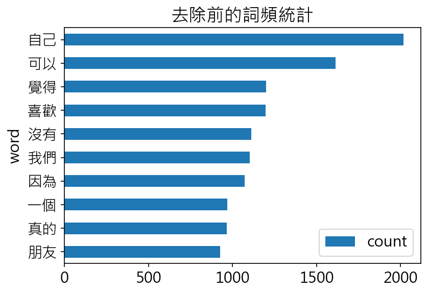

```python
freq_df = pd.DataFrame(word_df['word'].value_counts()).sort_values(by = ['count'], ascending = False).reset_index()
freq_df.head(10).plot.barh(x = 'word', y = 'count').invert_yaxis()
plt.title("去除前的詞頻統計")
plt.show()
```

```python
# 移除停用字，以檔案形式匯入通用的停用字檔案
# 將stopwords存成list
stopwords = [line.strip() for line in open('dict/stopwords.txt', 'r', encoding='utf-8').readlines()]

# 參數形式手動加入停用字
user_stop = ["可以", "覺得", "沒有", "我們", "因為", "一個", "一點","一下","一直","真的"]
for i in user_stop:
    stopwords.append(i)

noStop_df = word_df[~word_df['word'].isin(stopwords)]
noStop_df.head(5)
```

|  | artDate | artTitle | artContent | boardID | commentCount | gender | word |
| --- | --- | --- | --- | --- | --- | --- | --- |
| 0 | 2024-12-31 | 為什麼I人可以用I來當作不社交的藉口 | 如題，MBTI現在很紅，但我很不解有些I人常常碰到需要溝通的事情就說自己是I人，然後就把東西... | talk | 104 | M | 如題 |
| 1 | 2024-12-31 | 為什麼I人可以用I來當作不社交的藉口 | 如題，MBTI現在很紅，但我很不解有些I人常常碰到需要溝通的事情就說自己是I人，然後就把東西... | talk | 104 | M | MBTI |
| 1 | 2024-12-31 | 為什麼I人可以用I來當作不社交的藉口 | 如題，MBTI現在很紅，但我很不解有些I人常常碰到需要溝通的事情就說自己是I人，然後就把東西... | talk | 104 | M | 現在 |
| 1 | 2024-12-31 | 為什麼I人可以用I來當作不社交的藉口 | 如題，MBTI現在很紅，但我很不解有些I人常常碰到需要溝通的事情就說自己是I人，然後就把東西... | talk | 104 | M | 很紅 |
| 2 | 2024-12-31 | 為什麼I人可以用I來當作不社交的藉口 | 如題，MBTI現在很紅，但我很不解有些I人常常碰到需要溝通的事情就說自己是I人，然後就把東西... | talk | 104 | M | 不解 |

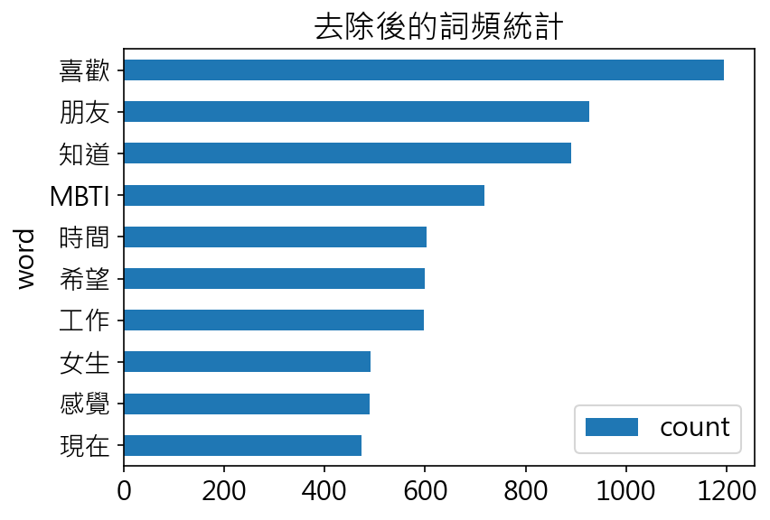

```python
freq_df_nostop = pd.DataFrame(pd.value_counts(noStop_df['word'])).sort_values(by = ['count'], ascending = False).reset_index()
freq_df_nostop.head(10).plot.barh(x = 'word', y = 'count').invert_yaxis()
plt.title("去除後的詞頻統計")
plt.show()
```

### 繪製文字雲

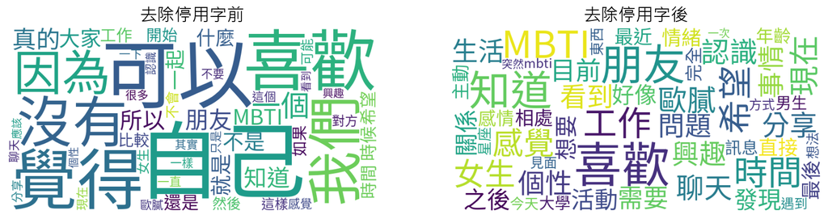

```python
# wordcloud的輸入須為dict，因此先將freq_df轉換成成dict
# 去除停用字前
freq_dict = freq_df.set_index('word').to_dict()
freq_dict = freq_dict['count']
# 去除停用字後
freq_dict_nostop = freq_df_nostop.set_index('word').to_dict()
freq_dict_nostop = freq_dict_nostop['count']

# 去除停用字前
wordcloud = WordCloud(background_color = 'white', width = 800, height = 400, font_path = FontPath, max_words = 50)
wordcloud.generate_from_frequencies(freq_dict)

# 去除停用字後
wordcloud_after = WordCloud(background_color = 'white', width = 800, height = 400, font_path = FontPath, max_words = 50)
wordcloud_after.generate_from_frequencies(freq_dict_nostop)

plt.figure(figsize = (14,8))

plt.subplot(1,2,1)
plt.imshow(wordcloud)
plt.axis('off')
plt.title("去除停用字前")

plt.subplot(1,2,2)
plt.imshow(wordcloud_after)
plt.axis('off')
plt.title("去除停用字後")

plt.show()
```

```python
noStop_df.head(5)
```

|  | artDate | artTitle | artContent | boardID | commentCount | gender | word |
| --- | --- | --- | --- | --- | --- | --- | --- |
| 0 | 2024-12-31 | 為什麼I人可以用I來當作不社交的藉口 | 如題，MBTI現在很紅，但我很不解有些I人常常碰到需要溝通的事情就說自己是I人，然後就把東西... | talk | 104 | M | 如題 |
| 1 | 2024-12-31 | 為什麼I人可以用I來當作不社交的藉口 | 如題，MBTI現在很紅，但我很不解有些I人常常碰到需要溝通的事情就說自己是I人，然後就把東西... | talk | 104 | M | MBTI |
| 1 | 2024-12-31 | 為什麼I人可以用I來當作不社交的藉口 | 如題，MBTI現在很紅，但我很不解有些I人常常碰到需要溝通的事情就說自己是I人，然後就把東西... | talk | 104 | M | 現在 |
| 1 | 2024-12-31 | 為什麼I人可以用I來當作不社交的藉口 | 如題，MBTI現在很紅，但我很不解有些I人常常碰到需要溝通的事情就說自己是I人，然後就把東西... | talk | 104 | M | 很紅 |
| 2 | 2024-12-31 | 為什麼I人可以用I來當作不社交的藉口 | 如題，MBTI現在很紅，但我很不解有些I人常常碰到需要溝通的事情就說自己是I人，然後就把東西... | talk | 104 | M | 不解 |

# 情緒分析

### 情緒字典與斷詞結果進行合併

```python
# 讀取情緒字典
liwc_dict = pd.read_csv("./dict/liwc/LIWC_CH.csv")
liwc_dict = liwc_dict.rename(columns={'name': 'word', "class": 'sentiments'})

mbti_liwc_df = pd.merge(noStop_df[["artDate", "artTitle", "artContent", "word"]], liwc_dict, how="left")
mbti_liwc_df.head(5)
```

|  | artDate | artTitle | artContent | word | sentiments |
| --- | --- | --- | --- | --- | --- |
| 0 | 2024-12-31 | 為什麼I人可以用I來當作不社交的藉口 | 如題，MBTI現在很紅，但我很不解有些I人常常碰到需要溝通的事情就說自己是I人，然後就把東西... | 如題 | NaN |
| 1 | 2024-12-31 | 為什麼I人可以用I來當作不社交的藉口 | 如題，MBTI現在很紅，但我很不解有些I人常常碰到需要溝通的事情就說自己是I人，然後就把東西... | MBTI | NaN |
| 2 | 2024-12-31 | 為什麼I人可以用I來當作不社交的藉口 | 如題，MBTI現在很紅，但我很不解有些I人常常碰到需要溝通的事情就說自己是I人，然後就把東西... | 現在 | NaN |
| 3 | 2024-12-31 | 為什麼I人可以用I來當作不社交的藉口 | 如題，MBTI現在很紅，但我很不解有些I人常常碰到需要溝通的事情就說自己是I人，然後就把東西... | 很紅 | NaN |
| 4 | 2024-12-31 | 為什麼I人可以用I來當作不社交的藉口 | 如題，MBTI現在很紅，但我很不解有些I人常常碰到需要溝通的事情就說自己是I人，然後就把東西... | 不解 | affect |

### 1.正負向情緒詞彙頻率折線圖圖

`情緒分析指標` 在情緒分析中，我們會以不同的指標來看情緒的好壞，其中常見的包含：

1. **情感詞彙頻率**： 使用情感詞彙列表，其中包含正向和負向情感的詞彙。將文本中的詞與該列表進行匹配，計算正向和負向詞彙的出現次數，從而判斷整體情感傾向。
2. **情感詞彙比例**：不同於單純的計算頻率，比例是某種情緒（例如：正向）佔所有情緒詞中的幾分之幾。這種方法可以避免某一天文章數特別多（詞頻也會隨之變多）而影響情緒的判斷。
3. **情感詞彙分數**： 給每個情感詞彙分配一個權重或分數，然後計算文本中所有情感詞的總分。這種方法允許區分不同情感詞的影響力，進一步細化情感分析的結果。

```python
sentiment_count = pd.DataFrame(
    mbti_liwc_df.groupby(["artDate", "sentiments"]).size()
).reset_index()

mask = (sentiment_count['sentiments'] == "positive") | (sentiment_count['sentiments'] == "negative")
sentiment_count = sentiment_count.loc[mask]

sentiment_count = sentiment_count.rename(columns={0: "size"})
sentiment_count = sentiment_count.sort_values(["artDate"])
sentiment_count.head(10)
```

|  | artDate | sentiments | size |
| --- | --- | --- | --- |
| 3 | 2024-01-01 | negative | 15 |
| 4 | 2024-01-01 | positive | 17 |
| 8 | 2024-01-02 | negative | 16 |
| 9 | 2024-01-02 | positive | 31 |
| 14 | 2024-01-03 | negative | 9 |
| 15 | 2024-01-03 | positive | 5 |
| 20 | 2024-01-04 | negative | 10 |
| 21 | 2024-01-04 | positive | 14 |
| 27 | 2024-01-05 | positive | 28 |
| 26 | 2024-01-05 | negative | 11 |

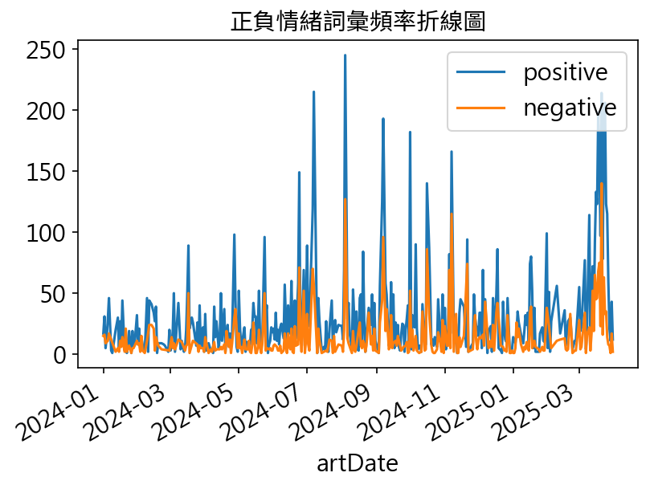

```python
colors = ["tab:blue", "tab:orange"]
pos = sentiment_count[sentiment_count["sentiments"] == "positive"]
neg = sentiment_count[sentiment_count["sentiments"] == "negative"]

# fig, ax = plt.subplots(figsize = (6,4), dpi = 150) # 也可以在該圖設定參數
fig, ax = plt.subplots()

ax.plot(pos["artDate"], pos["size"], color=colors[0])
ax.plot(neg["artDate"], neg["size"], color=colors[1])

plt.xlabel("artDate")
# plt.ylabel('size')
ax.legend(["positive", "negative"], loc="upper right")
fig.autofmt_xdate()
plt.title("正負情緒詞彙頻率折線圖", fontproperties=fprop)  # 記得加上才能顯示中文
plt.show()
```

`Moving average`

- 滾動平均是一種將時間序列數據平滑化的技術，有助於去除數據中的噪聲，使趨勢更加明顯，同時仍然保留一定的時間特徵。
- 在情緒分析中，特別是當你有一系列時間序列的情緒數據時，使用滾動平均有助於平滑數據，使情緒趨勢更加清晰。
  1. **去除瞬間噪聲**： 情緒數據可能受到瞬間事件或噪聲的影響，例如突發的大量評論或新聞。滾動平均有助於平滑這些突變，使你更容易觀察到整體趨勢。
  2. **強調長期趨勢**： 滾動平均有助於強調長期情緒趨勢，而不受短期波動的干擾。這對於觀察情緒的漸變和長期變化非常有用。

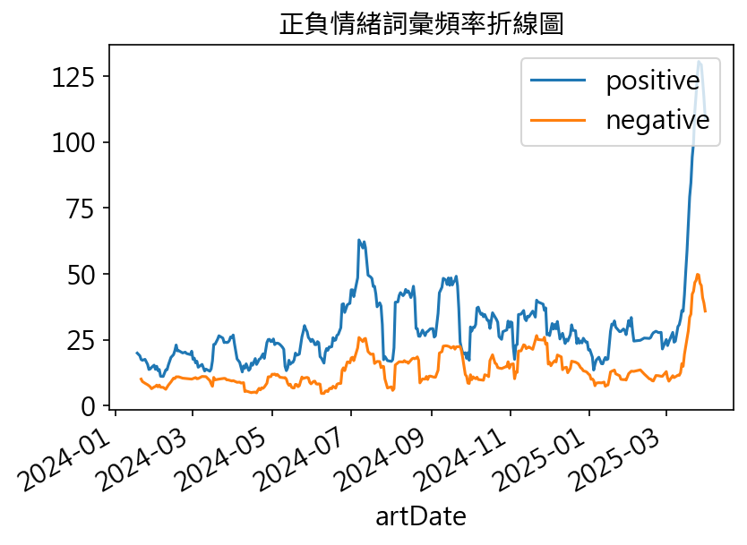

```python
colors = ["tab:blue", "tab:orange"]
pos = sentiment_count[sentiment_count["sentiments"] == "positive"]
neg = sentiment_count[sentiment_count["sentiments"] == "negative"]

# fig, ax = plt.subplots(figsize = (6,4), dpi = 150) # 也可以在該圖設定參數
fig, ax = plt.subplots()

# 使用 Series.rolling().mean() 來產生 14 天平均
rolling_days = 14
ax.plot(pos["artDate"], pos['size'].rolling(rolling_days).mean(), color=colors[0])
ax.plot(neg["artDate"], neg["size"].rolling(rolling_days).mean(), color=colors[1])

plt.xlabel("artDate")
# plt.ylabel('size')
ax.legend(["positive", "negative"], loc="upper right")
fig.autofmt_xdate()
plt.title("正負情緒詞彙頻率折線圖", fontproperties=fprop)  # 記得加上才能顯示中文
plt.show()
```

畫出每天的情緒總分數，可以看到正面的詞出現頻率幾乎每天都超過負面，是個氣氛和諧的討論版。

### 2.正負向情緒詞彙比例折線圖圖

```python
sentiment_count = sentiment_count.assign(
    ratio=sentiment_count.groupby("artDate")["size"].transform(lambda n: n / n.sum())
)
sentiment_count.head(5)
```

|  | artDate | sentiments | size | ratio |
| --- | --- | --- | --- | --- |
| 3 | 2024-01-01 | negative | 15 | 0.468750 |
| 4 | 2024-01-01 | positive | 17 | 0.531250 |
| 8 | 2024-01-02 | negative | 16 | 0.340426 |
| 9 | 2024-01-02 | positive | 31 | 0.659574 |
| 14 | 2024-01-03 | negative | 9 | 0.642857 |

```python
pos = sentiment_count[sentiment_count["sentiments"] == "positive"]
neg = sentiment_count[sentiment_count["sentiments"] == "negative"]
```

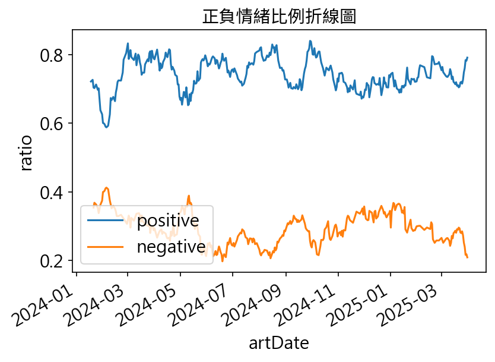

```python
fig, ax = plt.subplots()

rolling_days = 14
ax.plot(pos["artDate"], pos["ratio"].rolling(rolling_days).mean(), color=colors[0])
ax.plot(neg["artDate"], neg["ratio"].rolling(rolling_days).mean(), color=colors[1])

plt.xlabel("artDate")
plt.ylabel("ratio")
ax.legend(["positive", "negative"], loc="lower left")
fig.autofmt_xdate()
plt.title("正負情緒比例折線圖", fontproperties=fprop)
```

### 3.正負向情緒分數折線圖

```python
sentiment_count.head(5)
```

|  | artDate | sentiments | size | ratio |
| --- | --- | --- | --- | --- |
| 3 | 2024-01-01 | negative | 15 | 0.468750 |
| 4 | 2024-01-01 | positive | 17 | 0.531250 |
| 8 | 2024-01-02 | negative | 16 | 0.340426 |
| 9 | 2024-01-02 | positive | 31 | 0.659574 |
| 14 | 2024-01-03 | negative | 9 | 0.642857 |

```python
mbti_sentiment_value = (
    sentiment_count.pivot_table(
        index="artDate", columns="sentiments", values="size", fill_value=0
    )
    .reset_index()
    .rename_axis(None, axis=1)
)
mbti_sentiment_value.head()
```

|  | artDate | negative | positive |
| --- | --- | --- | --- |
| 0 | 2024-01-01 | 15.0 | 17.0 |
| 1 | 2024-01-02 | 16.0 | 31.0 |
| 2 | 2024-01-03 | 9.0 | 5.0 |
| 3 | 2024-01-04 | 10.0 | 14.0 |
| 4 | 2024-01-05 | 11.0 | 28.0 |

```python
# sentiment 計算方式: positive - negative
mbti_sentiment_value["sentiment_value"] = (
    mbti_sentiment_value["positive"]
    - mbti_sentiment_value["negative"]
)
mbti_sentiment_value.head()
```

|  | artDate | negative | positive | sentiment_value |
| --- | --- | --- | --- | --- |
| 0 | 2024-01-01 | 15.0 | 17.0 | 2.0 |
| 1 | 2024-01-02 | 16.0 | 31.0 | 15.0 |
| 2 | 2024-01-03 | 9.0 | 5.0 | -4.0 |
| 3 | 2024-01-04 | 10.0 | 14.0 | 4.0 |
| 4 | 2024-01-05 | 11.0 | 28.0 | 17.0 |

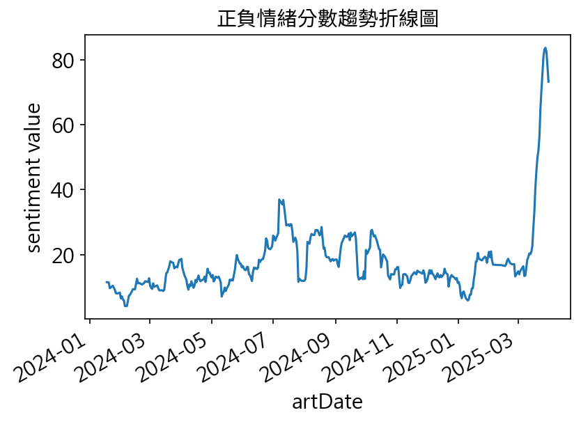

```python
fig, ax = plt.subplots()

rolling_days = 14
ax.plot(mbti_sentiment_value["artDate"], mbti_sentiment_value["sentiment_value"].rolling(rolling_days).mean())
ax.set_xlabel("artDate")
ax.set_ylabel("sentiment value")
fig.autofmt_xdate()
plt.title("正負情緒分數趨勢折線圖", fontproperties=fprop)
```

### 文章為單位的情緒分析

```python
sentiment_count_by_article = pd.DataFrame(
    mbti_liwc_df.groupby(["artTitle", "sentiments"]).size()
).reset_index()
sentiment_count_by_article = sentiment_count_by_article.rename(columns={0: "size"})
sentiment_count_by_article.head(5)
```

|  | artTitle | sentiments | size |
| --- | --- | --- | --- |
| 0 | #MBTI 新版 | affect | 1 |
| 1 | #其他 MBTI是ISTP-T的獅子座的我 | affect | 2 |
| 2 | #其他 MBTI是ISTP-T的獅子座的我 | anx | 1 |
| 3 | #其他 MBTI是ISTP-T的獅子座的我 | negative | 1 |
| 4 | #其他 MBTI是ISTP-T的獅子座的我 | positive | 1 |

```python
mbti_sentiment_value_by_article = (
    sentiment_count_by_article.pivot_table(
        index="artTitle", columns="sentiments", values="size", fill_value=0
    )
    .reset_index()
    .rename_axis(None, axis=1)
)
mbti_sentiment_value_by_article.head()
```

|  | artTitle | affect | anger | anx | negative | positive | sad |
| --- | --- | --- | --- | --- | --- | --- | --- |
| 0 | #MBTI 新版 | 1.0 | 0.0 | 0.0 | 0.0 | 0.0 | 0.0 |
| 1 | #其他 MBTI是ISTP-T的獅子座的我 | 2.0 | 0.0 | 1.0 | 1.0 | 1.0 | 0.0 |
| 2 | #其他 摩羯男被動還是主動？ | 10.0 | 0.0 | 1.0 | 4.0 | 4.0 | 0.0 |
| 3 | #其他 首爾陪玩翻譯 | 10.0 | 0.0 | 0.0 | 3.0 | 7.0 | 0.0 |
| 4 | #分享 P人式購物 跟著路人買日本最新必買的藥妝保養 | 12.0 | 3.0 | 0.0 | 3.0 | 7.0 | 0.0 |

```python
# sentiment 計算方式: positive - negative
mbti_sentiment_value_by_article["sentiment_value"] = (
    mbti_sentiment_value_by_article["positive"]
    - mbti_sentiment_value_by_article["negative"]
)
mbti_sentiment_value_by_article.head()
```

|  | artTitle | affect | anger | anx | negative | positive | sad | sentiment_value |
| --- | --- | --- | --- | --- | --- | --- | --- | --- |
| 0 | #MBTI 新版 | 1.0 | 0.0 | 0.0 | 0.0 | 0.0 | 0.0 | 0.0 |
| 1 | #其他 MBTI是ISTP-T的獅子座的我 | 2.0 | 0.0 | 1.0 | 1.0 | 1.0 | 0.0 | 0.0 |
| 2 | #其他 摩羯男被動還是主動？ | 10.0 | 0.0 | 1.0 | 4.0 | 4.0 | 0.0 | 0.0 |
| 3 | #其他 首爾陪玩翻譯 | 10.0 | 0.0 | 0.0 | 3.0 | 7.0 | 0.0 | 4.0 |
| 4 | #分享 P人式購物 跟著路人買日本最新必買的藥妝保養 | 12.0 | 3.0 | 0.0 | 3.0 | 7.0 | 0.0 | 4.0 |

```python
mbti_sentiment_value_by_article['sentiment_class'] = mbti_sentiment_value_by_article['sentiment_value'].apply(lambda x: "正向" if x > 0 else "負向" )
mbti_sentiment_value_by_article.head(5)
```

|  | artTitle | affect | anger | anx | negative | positive | sad | sentiment_value | sentiment_class |
| --- | --- | --- | --- | --- | --- | --- | --- | --- | --- |
| 0 | #MBTI 新版 | 1.0 | 0.0 | 0.0 | 0.0 | 0.0 | 0.0 | 0.0 | 負向 |
| 1 | #其他 MBTI是ISTP-T的獅子座的我 | 2.0 | 0.0 | 1.0 | 1.0 | 1.0 | 0.0 | 0.0 | 負向 |
| 2 | #其他 摩羯男被動還是主動？ | 10.0 | 0.0 | 1.0 | 4.0 | 4.0 | 0.0 | 0.0 | 負向 |
| 3 | #其他 首爾陪玩翻譯 | 10.0 | 0.0 | 0.0 | 3.0 | 7.0 | 0.0 | 4.0 | 正向 |
| 4 | #分享 P人式購物 跟著路人買日本最新必買的藥妝保養 | 12.0 | 3.0 | 0.0 | 3.0 | 7.0 | 0.0 | 4.0 | 正向 |

```python
clear_df_sentiment = pd.merge(df, mbti_sentiment_value_by_article[['artTitle', 'sentiment_class']], how="left")
clear_df_sentiment["artDate"] = pd.to_datetime(clear_df_sentiment["artDate"])
clear_df_sentiment['artDate'] = clear_df_sentiment['artDate'].dt.date

clear_df_sentiment.head()
```

|  | system_id | dataSource | artUrl | artDate | artTitle | artContent | boardID | commentCount | department | gender | school | sentiment_class |
| --- | --- | --- | --- | --- | --- | --- | --- | --- | --- | --- | --- | --- |
| 0 | 1 | Dcard | https://www.dcard.tw/f/talk/p/257640963 | 2024-12-31 | 為什麼I人可以用I來當作不社交的藉口 | 如題，MBTI現在很紅，但我很不解有些I人常常碰到需要溝通的事情就說自己是I人，然後就把東西... | talk | 104 | NaN | M | 國立臺灣大學 | 正向 |
| 1 | 2 | Dcard | https://www.dcard.tw/f/rainbow/p/257627205 | 2024-12-29 | 這麼剛好！ | 我和她的相遇，在盛夏。\n\n而偏偏，這個夏，颱風特別多，所以緣分恰似撞在了颱風眼上， 悄無... | rainbow | 1 | NaN | F | NaN | 正向 |
| 2 | 3 | Dcard | https://www.dcard.tw/f/mood/p/257619302 | 2024-12-28 | 不回應就是不喜歡 | 雖然知道不管是星座還是MBTI都是參考用，\n但不管過了多久，還是會去翻看有關於你的一切，好... | mood | 3 | NaN | F | NaN | NaN |
| 3 | 4 | Dcard | https://www.dcard.tw/f/rainbow/p/257635779 | 2024-12-30 | 不知道姐姐對我有沒有好感 | 12/23在迪卡上認識了一個姐姐\n到今天已經連續聊一個禮拜\n因為我想說慢慢來所以聊的沒有... | rainbow | 0 | NaN | F | NaN | 正向 |
| 4 | 5 | Dcard | https://www.dcard.tw/f/mood/p/257603606 | 2024-12-26 | 不去要ig就很膽小？？？ | 今天剛好悠閒來測mbti然後，我測試出來的是ENFP，我就把這個測試結果放在ig便利貼裡面，... | mood | 9 | NaN | F | NaN | 正向 |

```python
sentiment_art_count = pd.DataFrame(
    clear_df_sentiment.groupby(["artDate", "sentiment_class"]).size()
).reset_index()
sentiment_art_count = sentiment_art_count.rename(columns={0: "size"})
sentiment_art_count = sentiment_art_count.sort_values(["artDate"])
sentiment_art_count
```

|  | artDate | sentiment_class | size |
| --- | --- | --- | --- |
| 0 | 2024-01-01 | 正向 | 1 |
| 1 | 2024-01-02 | 正向 | 1 |
| 2 | 2024-01-02 | 負向 | 2 |
| 3 | 2024-01-03 | 負向 | 1 |
| 4 | 2024-01-04 | 正向 | 1 |
| ... | ... | ... | ... |
| 452 | 2025-03-28 | 正向 | 2 |
| 453 | 2025-03-29 | 正向 | 1 |
| 454 | 2025-03-30 | 正向 | 4 |
| 455 | 2025-03-31 | 正向 | 2 |
| 456 | 2025-03-31 | 負向 | 1 |

457 rows × 3 columns

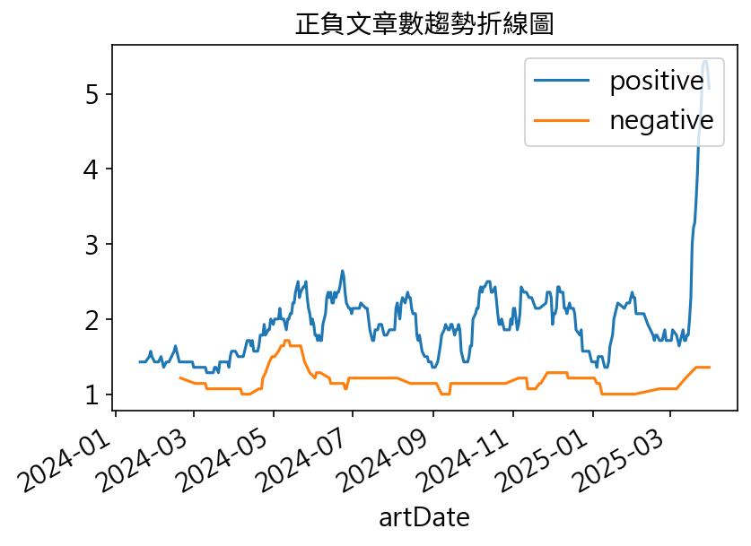

```python
colors = ["tab:blue", "tab:orange"]
pos = sentiment_art_count[sentiment_art_count["sentiment_class"] == "正向"]
neg = sentiment_art_count[sentiment_art_count["sentiment_class"] == "負向"]

# fig, ax = plt.subplots(figsize = (6,4), dpi = 150) # 也可以在該圖設定參數
fig, ax = plt.subplots()

# 使用 Series.rolling().mean() 來產生 14 天平均
rolling_days = 14
ax.plot(pos["artDate"], pos['size'].rolling(rolling_days).mean(), color=colors[0])
ax.plot(neg["artDate"], neg["size"].rolling(rolling_days).mean(), color=colors[1])
# ax.plot(pos["artDate"], pos['size'], color=colors[0])
# ax.plot(neg["artDate"], neg["size"], color=colors[1])

plt.xlabel("artDate")
# plt.ylabel('size')
ax.legend(["positive", "negative"], loc="upper right")
fig.autofmt_xdate()
plt.title("正負文章數趨勢折線圖", fontproperties=fprop)  # 記得加上才能顯示中文
plt.show()
```

大部分文章都被歸類在正向文章，MBTI討論內容大多偏正面

### 情緒代表字

```python
word_count = mbti_liwc_df.groupby(["word", "sentiments"]).size().reset_index()
word_count = word_count.rename(columns={0: "size"})
word_count = word_count.sort_values(["size"], ascending=False)

word_count.head(5)
```

|  | word | sentiments | size |
| --- | --- | --- | --- |
| 452 | 喜歡 | positive | 1196 |
| 451 | 喜歡 | affect | 1196 |
| 1184 | 朋友 | positive | 927 |
| 1183 | 朋友 | affect | 927 |
| 698 | 希望 | affect | 599 |

```python
word_of_pos = word_count.loc[(word_count["sentiments"] == "positive")]
word_of_pos.head(5)
```

|  | word | sentiments | size |
| --- | --- | --- | --- |
| 452 | 喜歡 | positive | 1196 |
| 1184 | 朋友 | positive | 927 |
| 699 | 希望 | positive | 599 |
| 250 | 分享 | positive | 389 |
| 1808 | 興趣 | positive | 375 |

```python
word_of_neg = word_count.loc[(word_count["sentiments"] == "negative")]
word_of_neg.head(5)
```

|  | word | sentiments | size |
| --- | --- | --- | --- |
| 439 | 問題 | negative | 360 |
| 854 | 情緒 | negative | 263 |
| 1786 | 自我 | negative | 172 |
| 1096 | 擔心 | negative | 89 |
| 518 | 壓力 | negative | 85 |

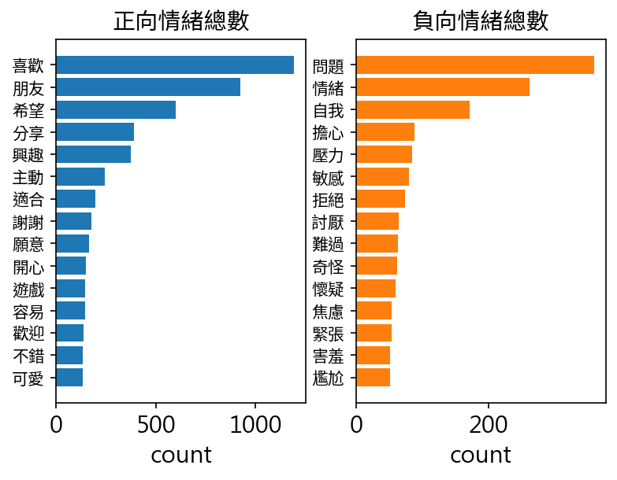

```python
pos = word_of_pos.head(15).sort_values(["size"], ascending=True)
neg = word_of_neg.head(15).sort_values(["size"], ascending=True)

fig, ax = plt.subplots(1, 2)

ax[0].barh(pos["word"], pos["size"], color=colors[0])
ax[0].set_xlabel("count")
ax[0].set_yticklabels(pos["word"], fontproperties=fprop)
ax[0].set_title("正向情緒總數", fontproperties=fprop)
ax[0].tick_params(axis='y', labelsize=10)

ax[1].barh(neg["word"], neg["size"], color=colors[1])
ax[1].set_xlabel("count")
ax[1].set_yticklabels(neg["word"], fontproperties=fprop)
ax[1].set_title("負向情緒總數", fontproperties=fprop)
ax[1].tick_params(axis='y', labelsize=10)
```

```python
# 安裝會使用到的套件
# 安裝ckiptagger前要先安裝tensorflow，有套件相依的問題
# %pip install -U ckiptagger\[tf,gdown\]
# %pip install wordcloud SnowNLP
# 確認當前工作目錄
# %pwd
```

```python
from ckiptagger import data_utils, construct_dictionary, WS, POS, NER
import time
import datetime
# data_utils.download_data_gdown("./")  # 下載ckip model
```

```
WARNING:tensorflow:From c:\Users\Rosie\Documents\研究所\社群媒體分析\SMA_finalProject\.venv\Lib\site-packages\keras\src\losses.py:2976: The name tf.losses.sparse_softmax_cross_entropy is deprecated. Please use tf.compat.v1.losses.sparse_softmax_cross_entropy instead.

WARNING:tensorflow:From c:\Users\Rosie\Documents\研究所\社群媒體分析\SMA_finalProject\.venv\Lib\site-packages\ckiptagger\api.py:8: The name tf.logging.set_verbosity is deprecated. Please use tf.compat.v1.logging.set_verbosity instead.
```

### 利用CKIP進行自然語言處理

- CKIP 標註任務
  - 斷詞（ws）
  - 實體辨識（ner）
  - 詞性標註（pos）

```python
# 將三份工具的模型路徑指向我們剛才下載的檔案「data」
ws = WS("./data")
pos = POS("./data")
ner = NER("./data")
```

```python
def Segmentation_Core(data, tokenizer):
    # 將所有的斷行字元配上 escape 以防失效
    regexPattern = '|'.join(map(re.escape, tokenizer))
    output_list = re.split(regexPattern, data)
    # 過濾空白行
    output_list = list(filter(None, output_list))
    return output_list

def Sentence_Segmentation(article, keep_digits=False, keep_alphabets=False):
    """ Sentence_Segmentation function 用於執行中文斷行任務

    順序如下：
    1. 去除(\\n)
    2. 去除特殊符號字元
    3. 保留數字
    4. 依照斷句字元進行斷句全形的分號、逗號、句號、問號以及驚嘆號
    5. 避免空白斷句結果

    Args:
        article(string): 欲斷行之文章內容
        keep_digits(Boolean): 決定是否保留數字於斷行後的結果
        keep_alphabets(Boolean): 決定是否保留字母於斷行後的結果
    Returns:
        List [] 每個 element 就是一行
    """
    sepical_symbols = r'[.＂<>:《》+\-=#$%&()*@＃＄％＆＇\(\)\[\]\{\}（）＊＋－／：\
    ＜＝＞＠［＼］＾＿｀｛｜｝～｟｠｢｣､、〃》「」『』【】〔〕〖〗〘〙〚〛〜〝〞〟〰〾〿–—一‘’‛“”„‟…‧﹏★→─]+'
    segmentation_used_note = (";", "；", "！", "!", "？", "?", "。")


    paragraphs = list(filter(lambda x: re.sub(r'\s+','', x), article.split("\n")))
    # print(len(paragraphs))
    # print(paragraphs)

    result = []
    for paragraph in paragraphs:

        clean_paragraph = paragraph
        try:
            if not keep_digits:
                clean_paragraph = re.sub(r'\d*\.?\d+','', clean_paragraph) #remove space & digits
            if not keep_alphabets:
                clean_paragraph = re.sub('[a-zA-Z]+', '', clean_paragraph)

            clean_paragraph = re.sub(r'[\s]+','', clean_paragraph) #remove space

            clean_paragraph = re.sub(sepical_symbols,'',clean_paragraph)

        except:
            return "error"

        res = Segmentation_Core(clean_paragraph, segmentation_used_note)
        result.append(res)

    return result
```

```python
# 自定義辭典
with open('dict/user_dict.txt', encoding='utf-8') as f:
    lines = f.read().splitlines()

dict = {k.split()[0]: k.split()[1] for v, k in enumerate(lines)}
dictionary2 = construct_dictionary(dict)
print(dictionary2)
```

```
[(2, {'內向': 500.0, '外向': 500.0, '直覺': 500.0, '感知': 500.0, '思考': 500.0, '情感': 500.0, 'E人': 500.0, 'I人': 500.0}), (3, {'共情力': 500.0}), (4, {'INFP': 500.0, 'INFJ': 500.0, 'INTP': 500.0, 'INTJ': 500.0, 'ENFP': 500.0, 'ENFJ': 500.0, 'ENTP': 500.0, 'ENTJ': 500.0, 'ISFP': 500.0, 'ISFJ': 500.0, 'ISTP': 500.…
```

```python
def get_pos(post_id, word_sentence, pos_sentence):
    tokens = []
    # print("\nPOS: ", end="\u3000")
    assert len(word_sentence) == len(pos_sentence)
    for word, pos in zip(word_sentence, pos_sentence): # token level
        tokens.append([post_id, word, pos])
    # print(f"{word}({pos})", end="\u3000")
    return tokens

def get_ner(post_id, entity_sentence):
    entities = []
    # print("\nNER:___________ ")
    for entity in sorted(entity_sentence): # token level
        entities.append([post_id, entity[3], entity[2]])
    return entities

import re

def get_nlp_result(data_df):
    start = time.time()

    pos_list = []
    entity_list = []
    sentence_list = []

    # 遍歷 dataframe 的每筆資料
    for index, row in data_df.iterrows(): # document level
        # 資料清理 ＆ 斷句
        article = str(row['artContent']) if pd.notna(row['artContent']) else ""
        tmp = Sentence_Segmentation(article, keep_alphabets=True)
        flat_list = [item for sublist in tmp for item in sublist]

        # 清理 flat_list 中的特殊字符
        flat_list = [re.sub(r'[^\u4e00-\u9fff\w\s.,!?]', '', sentence) for sentence in flat_list]

        # 清除 flat_list 中的網址
        flat_list = [re.sub(r'http\S+|www\S+', '', sentence) for sentence in flat_list]

        # ckip
        word_sentence_list = ws(flat_list, coerce_dictionary=dictionary2)
        pos_sentence_list = pos(word_sentence_list)
        entity_sentence_list = ner(word_sentence_list, pos_sentence_list)

        # 遍歷該 document 中的每一個句子
        for i, sentence in enumerate(flat_list):
            sentence_list.append([row['system_id'], sentence])
            temp_tokens = get_pos(row['system_id'], word_sentence_list[i], pos_sentence_list[i])
            temp_entites = get_ner(row['system_id'], entity_sentence_list[i])

            pos_list.append(temp_tokens)
            if len(temp_entites) != 0:
                entity_list.append(temp_entites)

    pos_flat = [item for sublist in pos_list for item in sublist]
    entity_flat = [item for sublist in entity_list for item in sublist]

    pos_table = pd.DataFrame(data=pos_flat,
                    columns=['system_id', 'word', 'pos'])

    entity_table = pd.DataFrame(data=entity_flat,
                        columns=['system_id', 'word', 'ner'])

    sentence_table = pd.DataFrame(data=sentence_list,
                    columns=['system_id', 'sentence'])

    end = time.time()
    print("time costing: {}".format(end - start))

    return pos_table, entity_table, sentence_table
```

```python
# 看看 tmp 和 flat_list 有什麼差別
tmp = Sentence_Segmentation(df['artContent'][0])
flat_list = [item for sublist in tmp for item in sublist]
print(tmp[:5])
print(flat_list[:5])
```

```
[['如題，現在很紅，但我很不解有些人常常碰到需要溝通的事情就說自己是人，然後就把東西丟給其他人去處理的這種心態'], ['我自己也是人，大學和剛出社會的時候甚至見客戶半個字都擠不出來，見到陌生人也是各種謎之尷尬', '但是我到處取經，不管是看影片問人上課，到處學習溝通的方式，至少能讓內向的我能不懼怕與陌生人交談，在與人溝通時不至於冷掉'], ['而我到現在做出來還是人', '我現在有變得喜歡社交嗎', '還是不喜歡', '只是我覺得很多人感覺都被限制了，只要是對生活工作有用的事情，就算不喜歡，為什麼不學呢', '所以我每次聽到我就內向人，那些社交的事給你們處理就好心裡就很火'], ['///…
['如題，現在很紅，但我很不解有些人常常碰到需要溝通的事情就說自己是人，然後就把東西丟給其他人去處理的這種心態', '我自己也是人，大學和剛出社會的時候甚至見客戶半個字都擠不出來，見到陌生人也是各種謎之尷尬', '但是我到處取經，不管是看影片問人上課，到處學習溝通的方式，至少能讓內向的我能不懼怕與陌生人交談，在與人溝通時不至於冷掉', '而我到現在做出來還是人', '我現在有變得喜歡社交嗎']
```

```python
pos_table, entity_table, sentence_table = get_nlp_result(df)
```

```
time costing: 185.2597029209137
```

- 欄位名稱介紹
  - pos_table 欄位:
    - system_id : MBTI 貼文id
    - word: 原始斷詞
    - pos : part-of-speech,詞性
  - entity_table 欄位:
    - system_id : MBTI 貼文id
    - word: 原始斷詞
    - ner: 命名實體
  - sentence_table 欄位:
    - system_id : MBTI 貼文id
    - sentence: 原始斷句

```python
pos_table.head() # word pos 列表
```

|  | system_id | word | pos |
| --- | --- | --- | --- |
| 0 | 1 | 如 | P |
| 1 | 1 | 題 | Na |
| 2 | 1 | MBTI | FW |
| 3 | 1 | 現在 | Nd |
| 4 | 1 | 很 | Dfa |

```python
entity_table.head() # word entity 列表
```

|  | system_id | word | ner |
| --- | --- | --- | --- |
| 0 | 1 | I人大學 | ORG |
| 1 | 1 | 半 | CARDINAL |
| 2 | 2 | 夏颱風 | EVENT |
| 3 | 2 | 十幾個小時 | TIME |
| 4 | 2 | 半夜 | TIME |

```python
sentence_table.head()
```

|  | system_id | sentence |
| --- | --- | --- |
| 0 | 1 | 如題MBTI現在很紅但我很不解有些I人常常碰到需要溝通的事情就說自己是I人然後就把東西丟給其... |
| 1 | 1 | 我自己也是I人大學和剛出社會的時候甚至見客戶半個字都擠不出來見到陌生人也是各種謎之尷尬 |
| 2 | 1 | 但是我到處取經不管是看影片問人上課到處學習溝通的方式至少能讓內向的我能不懼怕與陌生人交談在與... |
| 3 | 1 | 而我到現在MBTI做出來還是I人 |
| 4 | 1 | 我現在有變得喜歡社交嗎 |

```python
# 檢查筆數
print(f"total posts numbers: {len(pos_table['system_id'].unique())}") # 952篇文
print(f"posts have NER: {len(entity_table['system_id'].unique())}") # 704篇有抓到NER
```

```
total posts numbers: 954
posts have NER: 731
```

```python
# 將文章存成csv
pos_table.to_csv('raw_data/pos_table_buffet.csv', index = False)
entity_table.to_csv('raw_data/entity_table_buffet.csv', index = False)
sentence_table.to_csv('raw_data/sentence_table_buffet.csv', index = False)
```

### 探索分析 - NER

```python
# 讀取已經執行完畢的結果
pos_table = pd.read_csv("raw_data/pos_table_buffet.csv")
entity_table = pd.read_csv("raw_data/entity_table_buffet.csv")
sentence_table = pd.read_csv("raw_data/sentence_table_buffet.csv")
```

```python
entity_table['ner'].unique()
```

```
array(['ORG', 'CARDINAL', 'EVENT', 'TIME', 'DATE', 'PERSON', 'NORP',
       'GPE', 'FAC', 'WORK_OF_ART', 'PRODUCT', 'LOC', 'ORDINAL',
       'LANGUAGE', 'MONEY', 'QUANTITY', 'PERCENT', 'LAW'], dtype=object)
```

```python
ner_count = entity_table.groupby(['ner'])['ner'].count().reset_index(name='count').sort_values(['count'], ascending=False).head(10)
ner_count
```

|  | ner | count |
| --- | --- | --- |
| 1 | DATE | 1759 |
| 13 | PERSON | 1566 |
| 4 | GPE | 1088 |
| 0 | CARDINAL | 975 |
| 11 | ORG | 735 |
| 16 | TIME | 460 |
| 10 | ORDINAL | 353 |
| 5 | LANGUAGE | 272 |
| 9 | NORP | 269 |
| 14 | PRODUCT | 125 |

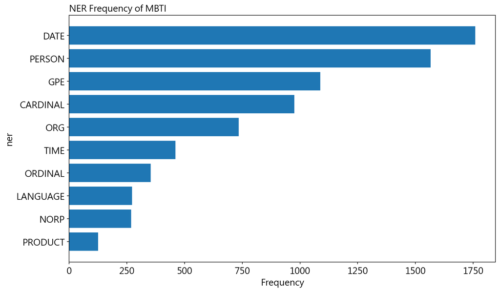

```python
ner = ner_count['ner']
count = ner_count['count']

fig, ax = plt.subplots(figsize =(12, 7))
ax.barh(ner, count)
ax.invert_yaxis()
ax.set_title('NER Frequency of MBTI',loc ='left', size = 14)
ax.set_ylabel('ner', size = 14)
ax.set_xlabel('Frequency', size = 14)
# fig.show()
```

### 涉及到的民族、宗教、政治團體(NORP)

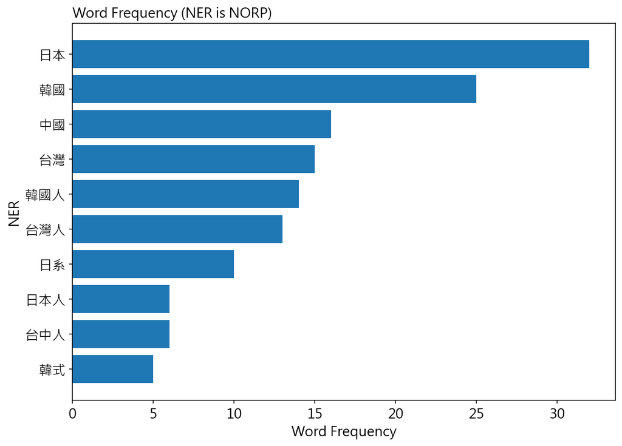

```python
# 篩選ner為NORP的資料
l_noun = ["NORP"]
NORP = entity_table[entity_table.ner.isin(l_noun)]

# # 計算每個名詞提到的次數，選出前10個
ner_count = NORP.groupby('word')['word'].agg(['count'])
ner_count = ner_count.sort_values(['count'],ascending=False)['count'].nlargest(10).reset_index()


# 設定中文字型
word = ner_count['word']
count = ner_count['count']

fig, ax = plt.subplots(figsize =(10, 7))
ax.barh(word, count)
ax.invert_yaxis()
ax.set_title('Word Frequency (NER is NORP)',loc ='left', size = 14)
ax.set_ylabel('NER', size = 14)
ax.set_xlabel('Word Frequency', size = 14)
# fig.show()
```

「日本」出現次數最多，其次是「韓國」、「中國」，顯示 MBTI 討論很常提到亞洲群體。 像是「日本」可能跟網友聊日本動漫或藥妝有關，「韓國」則可能提到韓國偶像，這些可能跟喜歡流行文化的性格有關，例如：動漫迷或是韓流追星的人。

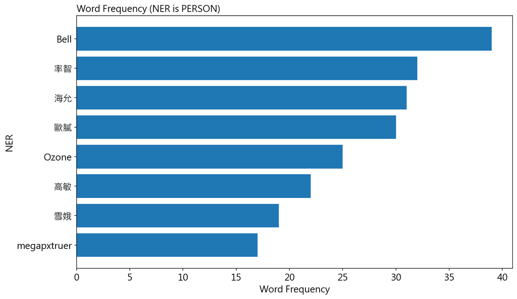

```python
# 篩選ner為PERSON的資料
l_noun = ["PERSON"]
PERSON = entity_table[entity_table.ner.isin(l_noun)]

# 計算每個名詞提到的次數，選出前8個
ner_count = PERSON.groupby('word')['word'].agg(['count'])
ner_count = ner_count.sort_values(['count'],ascending=False)['count'].nlargest(8).reset_index()

# 設定中文字型
word = ner_count['word']
count = ner_count['count']

fig, ax = plt.subplots(figsize =(12, 7))
ax.barh(word, count)
ax.invert_yaxis()
ax.set_title('Word Frequency (NER is PERSON)',loc ='left', size = 14)
ax.set_ylabel('NER', size = 14)
ax.set_xlabel('Word Frequency', size = 14)
# fig.show()
```

MBTI 討論中韓國女明星名字如「率智」、「海允」、「歐膩」居多，顯示女性角色活躍，可能跟愛聊韓國女星或韓流有關，反映MBTI議題喜歡討論韓國文化。 「高敏」可能隱含高敏感特質與內向或情感豐富的特質相關。 整體看來， MBTI 話題傾向討論女性角色；高敏則透露情緒敏感，與內向性格有關。

### 探索分析 - POS

```python
pos_table['pos'].unique()
```

```
array(['P', 'Na', 'FW', 'Nd', 'Dfa', 'VH', 'Cbb', 'Nh', 'VK', 'V_2', 'Nf',
       'D', 'VC', 'DE', 'VE', 'SHI', 'VD', 'Neqa', 'Nep', 'Nc', 'Caa',
       'VA', 'Nes', 'Da', 'VL', 'VJ', 'Ng', 'VB', 'VG', 'T', 'Di', 'Ncd',
       'Neu', 'VHC', 'Nv', 'VF', 'VCL', 'Nb', 'A', 'Dk', 'Cab', 'VI',
       'Dfb', 'I', 'VAC', 'Cba', 'COMMACATEGORY', 'DM', 'Neqb',
       'PARENTHESISCATEGORY'], dtype=object)
```

#### POS 常見詞性列表

- Na: 普通名詞
- D: 副詞
- VC: 動作及物動詞
- Nb: 專有名詞
- FW: 外文
- VH: 狀態不及物動詞
- Nh: 代名詞
- DE: 的之得地
- P: 介詞
- VA: 動作不及物動詞
- T: 語助詞
- SHI: 是

```python
pos_filter = pos_table[~pos_table.pos.isin(['COMMACATEGORY', 'PARENTHESISCATEGORY', 'PERIODCATEGORY', 'COLONCATEGORY'])]

pos_count = pos_filter.groupby(['pos'])['pos'].count().reset_index(name='count').sort_values(['count'], ascending=False).head(12)
pos_count
```

|  | pos | count |
| --- | --- | --- |
| 15 | Na | 57771 |
| 5 | D | 46356 |
| 27 | Nh | 27682 |
| 41 | VH | 22382 |
| 35 | VC | 21729 |
| 6 | DE | 18183 |
| 29 | P | 12809 |
| 38 | VE | 11169 |
| 32 | VA | 9727 |
| 4 | Cbb | 8719 |
| 25 | Nf | 8686 |
| 13 | FW | 8557 |

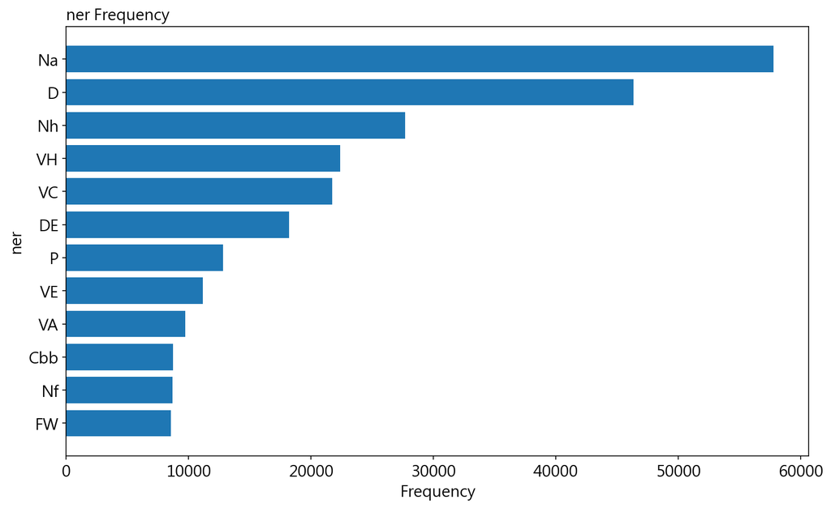

```python
pos = pos_count['pos']
count = pos_count['count']

fig, ax = plt.subplots(figsize =(12, 7))
ax.barh(pos, count)
ax.invert_yaxis()
ax.set_title('ner Frequency',loc ='left', size = 14)
ax.set_ylabel('ner', size = 14)
ax.set_xlabel('Frequency', size = 14)
fig.show()
```

### 涉及到的名詞(Noun)

- 我們可以找出談論MBTI時大部分討論到的名詞，探索大家的關注焦點。
- 名詞可以分為「Na: 普通名詞」、「Nb: 專有名詞」等

```python
# 篩選pos為專有名詞的資料
l_noun = ["Nb"] #,"Na"
noun = pos_table[pos_table.pos.isin(l_noun)]

# 計算每個名詞提到的次數，選出前5個
noun_count = noun[['word']].groupby(['word'])['word'].count().reset_index(name='count').sort_values(['count'], ascending=False).head(15)
noun_count.head(5)
```

|  | word | count |
| --- | --- | --- |
| 489 | 歐膩 | 253 |
| 523 | 海允 | 57 |
| 573 | 率智 | 26 |
| 787 | 迪士尼 | 25 |
| 731 | 處女座 | 22 |

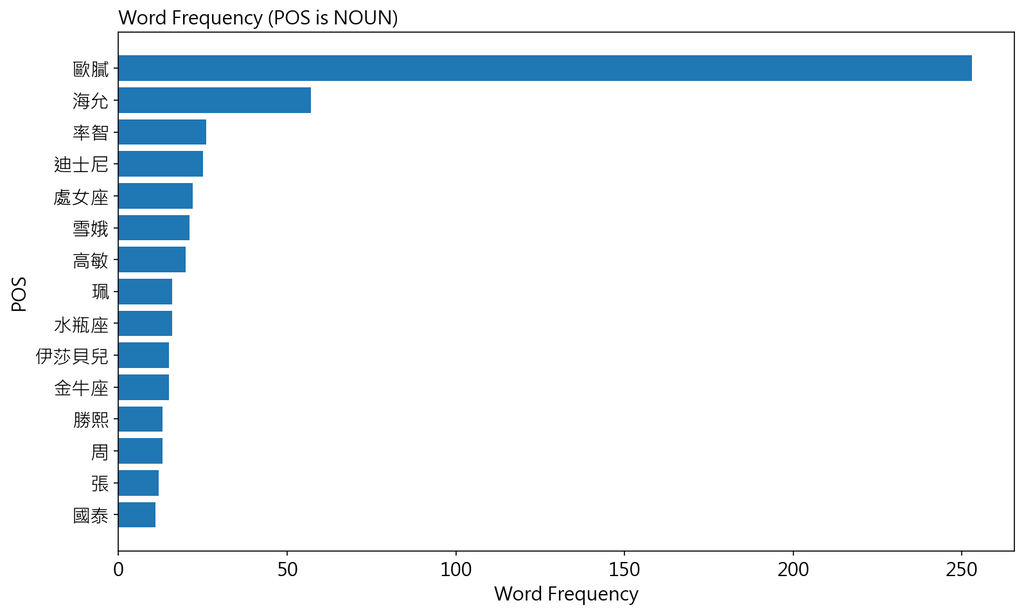

```python
# 設定中文字型
word = noun_count['word']
count = noun_count['count']

fig, ax = plt.subplots(figsize =(12, 7))
ax.barh(word, count)
ax.invert_yaxis()
ax.set_title('Word Frequency (POS is NOUN)',loc ='left', size = 14)
ax.set_ylabel('POS', size = 14)
ax.set_xlabel('Word Frequency', size = 14)
fig.show()
```

可以看到韓國女明星依舊是出現最多次的專有名詞，另外，從「處女座」、「水瓶座」和「金牛座」等專有名詞可以推測出大家對於星座也有較高的討論度。

### 涉及到的動詞(VERB)

- 我們可以找出談論MBTI時大部分討論到的動詞，探索相關行為。
- VC: 動作及物動詞、VH: 狀態不及物動詞、VA: 動作不及物動詞

```python
l_verb = ["VC"] # ,"VH","VA"
verb = pos_table[pos_table.pos.isin(l_verb)] # 選取特定詞性
verb = verb[verb['word'].map(len) > 1] # 把長度為1的字去除掉

verb_count = verb[['word']].groupby(['word'])['word'].count().reset_index(name='count').sort_values(['count'], ascending=False).head(15)
verb_count
```

|  | word | count |
| --- | --- | --- |
| 2349 | 遇到 | 227 |
| 1492 | 溝通 | 183 |
| 1038 | 接受 | 171 |
| 829 | 找到 | 149 |
| 334 | 參加 | 144 |
| 82 | 使用 | 125 |
| 1075 | 推薦 | 119 |
| 2378 | 選擇 | 116 |
| 336 | 參考 | 109 |
| 2511 | 面試 | 101 |
| 570 | 學習 | 99 |
| 1970 | 表達 | 96 |
| 2006 | 規劃 | 94 |
| 680 | 幫忙 | 90 |
| 676 | 幫助 | 89 |

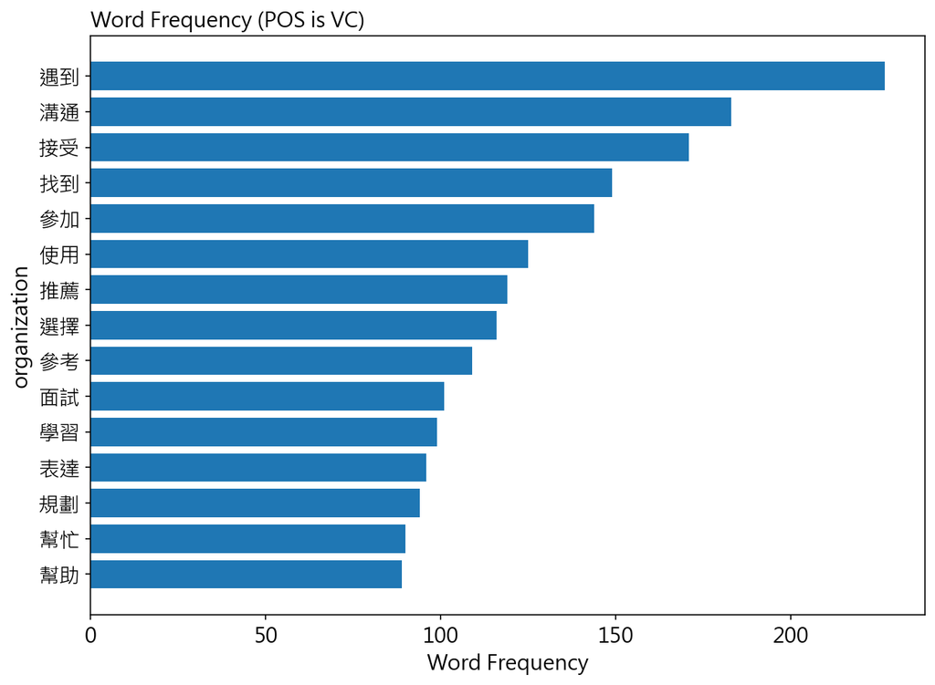

```python
word = verb_count['word']
count = verb_count['count']

fig, ax = plt.subplots(figsize =(10, 7))
ax.barh(word, count)
ax.invert_yaxis()
ax.set_title('Word Frequency (POS is VC)',loc ='left', size = 14)
ax.set_ylabel('organization', size = 14)
ax.set_xlabel('Word Frequency', size = 14)
fig.show()
```

發現在貼文中的動詞，「遇到」佔了相當高的頻率，其他還有出現「溝通」、「接受」等詞彙，可推測網友對於人際關係的處理方式有較高的討論程度。

## 利用SnowNLP進行情緒分析

- SnowNLP 針對中文設計，可以提取句子的情緒分類
- 使用文件分類法，套件已預先用文集訓練模型以判斷情緒
- 情緒值在 0~1之間，代表負面到正面

```python
# 載入原始資料 dataset_mbti.csv
shu_selected = pd.read_csv("raw_data\dataset_mbti.csv")

# 合併 sentence_table 與 shu_selected，提取 system_id、artDate 和 dataSource
sentiment_date = pd.merge(sentence_table, shu_selected[['system_id', 'artDate', 'dataSource']], on='system_id', how='left').dropna()

# 顯示前 3 行，確認結果
sentiment_date.head(3)
```

|  | system_id | sentence | artDate | dataSource |
| --- | --- | --- | --- | --- |
| 0 | 1 | 如題MBTI現在很紅但我很不解有些I人常常碰到需要溝通的事情就說自己是I人然後就把東西丟給其... | 2024-12-31 09:24:03 | Dcard |
| 1 | 1 | 我自己也是I人大學和剛出社會的時候甚至見客戶半個字都擠不出來見到陌生人也是各種謎之尷尬 | 2024-12-31 09:24:03 | Dcard |
| 2 | 1 | 但是我到處取經不管是看影片問人上課到處學習溝通的方式至少能讓內向的我能不懼怕與陌生人交談在與... | 2024-12-31 09:24:03 | Dcard |

```python
from snownlp import SnowNLP
def get_sentiment(sent):
    s = SnowNLP(sent)
    return s.sentiments

# 幫每句話加上情緒分數
sentiment_date['sentimentValue'] = sentiment_date.apply(lambda row : get_sentiment(row['sentence'],), axis = 1)
sentiment_date.head(3)
```

|  | system_id | sentence | artDate | dataSource | sentimentValue |
| --- | --- | --- | --- | --- | --- |
| 0 | 1 | 如題MBTI現在很紅但我很不解有些I人常常碰到需要溝通的事情就說自己是I人然後就把東西丟給其... | 2024-12-31 09:24:03 | Dcard | 0.003465 |
| 1 | 1 | 我自己也是I人大學和剛出社會的時候甚至見客戶半個字都擠不出來見到陌生人也是各種謎之尷尬 | 2024-12-31 09:24:03 | Dcard | 0.000003 |
| 2 | 1 | 但是我到處取經不管是看影片問人上課到處學習溝通的方式至少能讓內向的我能不懼怕與陌生人交談在與... | 2024-12-31 09:24:03 | Dcard | 0.000011 |

```python
# 看一下情緒的分布
sentiment_date['sentimentValue'].describe()
```

```
count    28475.000000
mean         0.409524
std          0.335173
min          0.000000
25%          0.078095
50%          0.364239
75%          0.699552
max          1.000000
Name: sentimentValue, dtype: float64
```

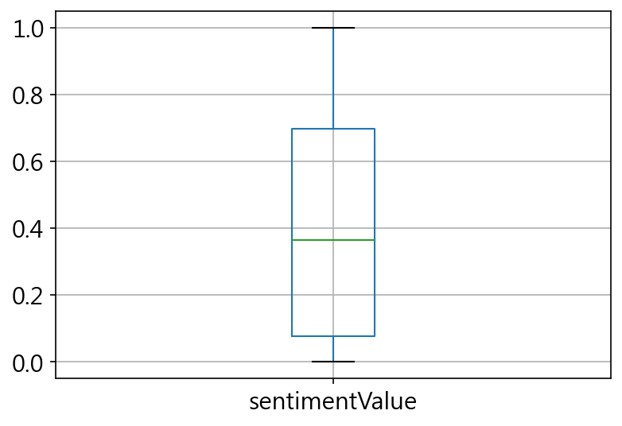

```python
# 情緒分布的盒狀圖
boxplot = sentiment_date.boxplot(column=['sentimentValue'], showfliers=False)
boxplot
```

將每個月的情緒分數取平均，並轉換時間格式為年月

```python
sent_date = sentiment_date.copy()
sent_date['artDate'] =  pd.to_datetime(sentiment_date['artDate']).dt.to_period('M')

sentiment_count = sent_date.groupby(['artDate'])['sentimentValue'].mean().reset_index()
sentiment_count
```

|  | artDate | sentimentValue |
| --- | --- | --- |
| 0 | 2024-01 | 0.418434 |
| 1 | 2024-02 | 0.402526 |
| 2 | 2024-03 | 0.423195 |
| 3 | 2024-04 | 0.426088 |
| 4 | 2024-05 | 0.445732 |
| 5 | 2024-06 | 0.433996 |
| 6 | 2024-07 | 0.439874 |
| 7 | 2024-08 | 0.379767 |
| 8 | 2024-09 | 0.394818 |
| 9 | 2024-10 | 0.387562 |
| 10 | 2024-11 | 0.424562 |
| 11 | 2024-12 | 0.402737 |
| 12 | 2025-01 | 0.390320 |
| 13 | 2025-02 | 0.383046 |
| 14 | 2025-03 | 0.409893 |

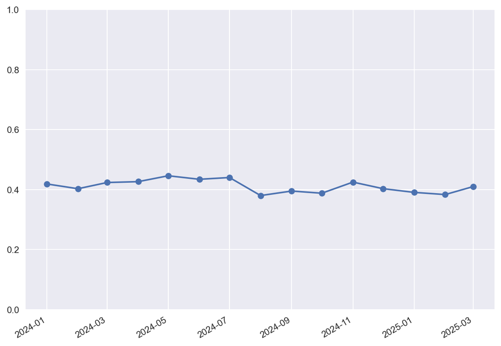

```python
# 平均情緒分數時間趨勢
months = [period.to_timestamp() for period in sentiment_count['artDate']]   # 將 PeriodIndex 中的每個 Period 物件轉換為對應的 datetime 物件
y = sentiment_count['sentimentValue']

plt.style.use('seaborn-v0_8')

plt.plot_date(months, y, linestyle='solid')
plt.gcf().autofmt_xdate()
plt.tight_layout()
plt.ylim(0, 1)

plt.show()
```

# 分析MBTI相關文章之詞彙關係

```python
import numpy as np
import jieba.analyse
import math
from nltk import ngrams, FreqDist
from collections import Counter, namedtuple

import networkx as nx
from sklearn.feature_extraction.text import CountVectorizer,TfidfTransformer
from sklearn.metrics.pairwise import cosine_similarity
```

```python
MetaData = df.copy()

# 去除一些不需要的欄位
MetaData = MetaData.drop(['dataSource', 'boardID', 'commentCount', 'department', 'gender', 'school'], axis=1)

# 只留下中文字，處理缺失值
MetaData['sentence'] = MetaData['artContent'].apply(lambda x: re.sub('[^\u4e00-\u9fff]+', '', str(x)) if pd.notna(x) else '')

MetaData.head(3)
```

|  | system_id | artUrl | artDate | artTitle | artContent | sentence |
| --- | --- | --- | --- | --- | --- | --- |
| 0 | 1 | https://www.dcard.tw/f/talk/p/257640963 | 2024-12-31 | 為什麼I人可以用I來當作不社交的藉口 | 如題，MBTI現在很紅，但我很不解有些I人常常碰到需要溝通的事情就說自己是I人，然後就把東西... | 如題現在很紅但我很不解有些人常常碰到需要溝通的事情就說自己是人然後就把東西丟給其他人去處理的... |
| 1 | 2 | https://www.dcard.tw/f/rainbow/p/257627205 | 2024-12-29 | 這麼剛好！ | 我和她的相遇，在盛夏。\n\n而偏偏，這個夏，颱風特別多，所以緣分恰似撞在了颱風眼上， 悄無... | 我和她的相遇在盛夏而偏偏這個夏颱風特別多所以緣分恰似撞在了颱風眼上悄無聲息襯著神秘讓人難覺往... |
| 2 | 3 | https://www.dcard.tw/f/mood/p/257619302 | 2024-12-28 | 不回應就是不喜歡 | 雖然知道不管是星座還是MBTI都是參考用，\n但不管過了多久，還是會去翻看有關於你的一切，好... | 雖然知道不管是星座還是都是參考用但不管過了多久還是會去翻看有關於你的一切好想知道你的想法即便... |

```python
# 設定繁體中文詞庫
jieba.set_dictionary('./dict/dict.txt.big')

# 新增stopwords
with open('./dict/stopwords.txt',encoding="utf-8") as f:
    stopWords = [line.strip() for line in f.readlines()]
```

```python
# 設定斷詞 function
def getToken(row):
    seg_list = jieba.lcut(row)
    seg_list = [w for w in seg_list if w not in stopWords and len(w)>1] # 篩選掉停用字與字元數小於1的詞彙

    return seg_list
```

```python
data = MetaData.copy()

# 斷詞、去除停用字並將word欄位展開
data['word'] = data.sentence.apply(getToken).explode('word')

data.head(3)
```

```
Building prefix dict from c:\Users\Rosie\Documents\研究所\社群媒體分析\SMA_finalProject\dict\dict.txt.big ...
Loading model from cache C:\Users\Rosie\AppData\Local\Temp\jieba.u9e434e2756c7e53fdc471cb01160378f.cache
Loading model cost 0.488 seconds.
Prefix dict has been built successfully.
```

|  | system_id | artUrl | artDate | artTitle | artContent | sentence | word |
| --- | --- | --- | --- | --- | --- | --- | --- |
| 0 | 1 | https://www.dcard.tw/f/talk/p/257640963 | 2024-12-31 | 為什麼I人可以用I來當作不社交的藉口 | 如題，MBTI現在很紅，但我很不解有些I人常常碰到需要溝通的事情就說自己是I人，然後就把東西... | 如題現在很紅但我很不解有些人常常碰到需要溝通的事情就說自己是人然後就把東西丟給其他人去處理的... | 現在 |
| 1 | 2 | https://www.dcard.tw/f/rainbow/p/257627205 | 2024-12-29 | 這麼剛好！ | 我和她的相遇，在盛夏。\n\n而偏偏，這個夏，颱風特別多，所以緣分恰似撞在了颱風眼上， 悄無... | 我和她的相遇在盛夏而偏偏這個夏颱風特別多所以緣分恰似撞在了颱風眼上悄無聲息襯著神秘讓人難覺往... | 很紅 |
| 2 | 3 | https://www.dcard.tw/f/mood/p/257619302 | 2024-12-28 | 不回應就是不喜歡 | 雖然知道不管是星座還是MBTI都是參考用，\n但不管過了多久，還是會去翻看有關於你的一切，好... | 雖然知道不管是星座還是都是參考用但不管過了多久還是會去翻看有關於你的一切好想知道你的想法即便... | 不解 |

## 找出重要詞彙 - 以TFIDF為例

```python
MBTI_df = MetaData.copy()
MBTI_df.head(3)
```

|  | system_id | artUrl | artDate | artTitle | artContent | sentence |
| --- | --- | --- | --- | --- | --- | --- |
| 0 | 1 | https://www.dcard.tw/f/talk/p/257640963 | 2024-12-31 | 為什麼I人可以用I來當作不社交的藉口 | 如題，MBTI現在很紅，但我很不解有些I人常常碰到需要溝通的事情就說自己是I人，然後就把東西... | 如題現在很紅但我很不解有些人常常碰到需要溝通的事情就說自己是人然後就把東西丟給其他人去處理的... |
| 1 | 2 | https://www.dcard.tw/f/rainbow/p/257627205 | 2024-12-29 | 這麼剛好！ | 我和她的相遇，在盛夏。\n\n而偏偏，這個夏，颱風特別多，所以緣分恰似撞在了颱風眼上， 悄無... | 我和她的相遇在盛夏而偏偏這個夏颱風特別多所以緣分恰似撞在了颱風眼上悄無聲息襯著神秘讓人難覺往... |
| 2 | 3 | https://www.dcard.tw/f/mood/p/257619302 | 2024-12-28 | 不回應就是不喜歡 | 雖然知道不管是星座還是MBTI都是參考用，\n但不管過了多久，還是會去翻看有關於你的一切，好... | 雖然知道不管是星座還是都是參考用但不管過了多久還是會去翻看有關於你的一切好想知道你的想法即便... |

```python
# 保留需要的欄位
MBTI_df = MBTI_df.loc[:,["system_id", "sentence"]]

# 改成使用空格連接斷完的詞
MBTI_df['word'] = MBTI_df.sentence.apply(getToken).map(' '.join)

MBTI_df.head()
```

|  | system_id | sentence | word |
| --- | --- | --- | --- |
| 0 | 1 | 如題現在很紅但我很不解有些人常常碰到需要溝通的事情就說自己是人然後就把東西丟給其他人去處理的... | 現在 很紅 不解 碰到 需要 溝通 事情 東西 丟給 其他人 處理 這種 心態 大學 剛出 ... |
| 1 | 2 | 我和她的相遇在盛夏而偏偏這個夏颱風特別多所以緣分恰似撞在了颱風眼上悄無聲息襯著神秘讓人難覺往... | 相遇 盛夏 颱風 特別 緣分 颱風眼 悄無聲息 襯著 神秘 難覺 往後 熱烈 記得 相遇 那... |
| 2 | 3 | 雖然知道不管是星座還是都是參考用但不管過了多久還是會去翻看有關於你的一切好想知道你的想法即便... | 知道 星座 參考 過了 多久 翻看 知道 想法 早就 知道 不在意 裝作 忙碌 應對 |
| 3 | 4 | 在迪卡上認識了一個姐姐到今天已經連續聊一個禮拜因為我想說慢慢來所以聊的沒有很多也沒有很主動但... | 迪卡上 認識 姐姐 今天 連續 禮拜 慢慢來 主動 擔心 禮貌性 回覆 一下 每天 聊天 一... |
| 4 | 5 | 今天剛好悠閒來測然後我測試出來的是我就把這個測試結果放在便利貼裡面晚上的時候朋友就留言我的便... | 今天 悠閒 來測 測試 測試 放在 便利 貼裡面 晚上 朋友 留言 便利 傻眼 貼圖 給我 ... |

```python
# Bag of Word
vectorizer = CountVectorizer()
X = vectorizer.fit_transform(MBTI_df["word"])
vocabulary = vectorizer.get_feature_names_out()

# 轉成 dataframe
DTM_df = pd.DataFrame(columns = vocabulary, data = X.toarray())
DTM_df
```

|  | 一一 | 一丁點 | 一上午 | 一上台 | 一下 | 一下下 | 一下四周 | 一下子 | 一不小心 | 一串 | ... | 齊全 | 齋戒 | 齒列 | 龍仁 | 龍山寺 | 龍科技 | 龍貓 | 龍馬 | 龐雜 | 龜毛 |
| --- | --- | --- | --- | --- | --- | --- | --- | --- | --- | --- | --- | --- | --- | --- | --- | --- | --- | --- | --- | --- | --- |
| 0 | 0 | 0 | 0 | 0 | 0 | 0 | 0 | 0 | 0 | 0 | ... | 0 | 0 | 0 | 0 | 0 | 0 | 0 | 0 | 0 | 0 |
| 1 | 0 | 0 | 0 | 0 | 0 | 0 | 0 | 0 | 0 | 0 | ... | 0 | 0 | 0 | 0 | 0 | 0 | 0 | 0 | 0 | 0 |
| 2 | 0 | 0 | 0 | 0 | 0 | 0 | 0 | 0 | 0 | 0 | ... | 0 | 0 | 0 | 0 | 0 | 0 | 0 | 0 | 0 | 0 |
| 3 | 0 | 0 | 0 | 0 | 1 | 0 | 0 | 0 | 0 | 0 | ... | 0 | 0 | 0 | 0 | 0 | 0 | 0 | 0 | 0 | 0 |
| 4 | 0 | 0 | 0 | 0 | 0 | 0 | 0 | 0 | 0 | 0 | ... | 0 | 0 | 0 | 0 | 0 | 0 | 0 | 0 | 0 | 0 |
| ... | ... | ... | ... | ... | ... | ... | ... | ... | ... | ... | ... | ... | ... | ... | ... | ... | ... | ... | ... | ... | ... |
| 969 | 0 | 0 | 0 | 0 | 0 | 0 | 0 | 0 | 0 | 0 | ... | 0 | 0 | 0 | 0 | 0 | 0 | 0 | 0 | 0 | 0 |
| 970 | 0 | 0 | 0 | 0 | 0 | 0 | 0 | 0 | 0 | 0 | ... | 0 | 0 | 0 | 0 | 0 | 0 | 0 | 0 | 0 | 0 |
| 971 | 0 | 0 | 0 | 0 | 0 | 0 | 0 | 0 | 0 | 0 | ... | 0 | 0 | 0 | 0 | 0 | 0 | 0 | 0 | 0 | 0 |
| 972 | 0 | 0 | 0 | 0 | 0 | 0 | 0 | 0 | 0 | 0 | ... | 0 | 0 | 0 | 0 | 0 | 0 | 0 | 0 | 0 | 0 |
| 973 | 0 | 0 | 0 | 0 | 0 | 0 | 0 | 0 | 0 | 0 | ... | 0 | 0 | 0 | 0 | 0 | 0 | 0 | 0 | 0 | 0 |

974 rows × 24586 columns

```python
transformer = TfidfTransformer()
# 將詞頻矩陣X統計成TF-IDF值
tfidf = transformer.fit_transform(X)

# 轉成dataframe
TFIDF_df = pd.DataFrame(columns = vocabulary, data = tfidf.toarray())

TFIDF_df
```

|  | 一一 | 一丁點 | 一上午 | 一上台 | 一下 | 一下下 | 一下四周 | 一下子 | 一不小心 | 一串 | ... | 齊全 | 齋戒 | 齒列 | 龍仁 | 龍山寺 | 龍科技 | 龍貓 | 龍馬 | 龐雜 | 龜毛 |
| --- | --- | --- | --- | --- | --- | --- | --- | --- | --- | --- | --- | --- | --- | --- | --- | --- | --- | --- | --- | --- | --- |
| 0 | 0.0 | 0.0 | 0.0 | 0.0 | 0.000000 | 0.0 | 0.0 | 0.0 | 0.0 | 0.0 | ... | 0.0 | 0.0 | 0.0 | 0.0 | 0.0 | 0.0 | 0.0 | 0.0 | 0.0 | 0.0 |
| 1 | 0.0 | 0.0 | 0.0 | 0.0 | 0.000000 | 0.0 | 0.0 | 0.0 | 0.0 | 0.0 | ... | 0.0 | 0.0 | 0.0 | 0.0 | 0.0 | 0.0 | 0.0 | 0.0 | 0.0 | 0.0 |
| 2 | 0.0 | 0.0 | 0.0 | 0.0 | 0.000000 | 0.0 | 0.0 | 0.0 | 0.0 | 0.0 | ... | 0.0 | 0.0 | 0.0 | 0.0 | 0.0 | 0.0 | 0.0 | 0.0 | 0.0 | 0.0 |
| 3 | 0.0 | 0.0 | 0.0 | 0.0 | 0.062889 | 0.0 | 0.0 | 0.0 | 0.0 | 0.0 | ... | 0.0 | 0.0 | 0.0 | 0.0 | 0.0 | 0.0 | 0.0 | 0.0 | 0.0 | 0.0 |
| 4 | 0.0 | 0.0 | 0.0 | 0.0 | 0.000000 | 0.0 | 0.0 | 0.0 | 0.0 | 0.0 | ... | 0.0 | 0.0 | 0.0 | 0.0 | 0.0 | 0.0 | 0.0 | 0.0 | 0.0 | 0.0 |
| ... | ... | ... | ... | ... | ... | ... | ... | ... | ... | ... | ... | ... | ... | ... | ... | ... | ... | ... | ... | ... | ... |
| 969 | 0.0 | 0.0 | 0.0 | 0.0 | 0.000000 | 0.0 | 0.0 | 0.0 | 0.0 | 0.0 | ... | 0.0 | 0.0 | 0.0 | 0.0 | 0.0 | 0.0 | 0.0 | 0.0 | 0.0 | 0.0 |
| 970 | 0.0 | 0.0 | 0.0 | 0.0 | 0.000000 | 0.0 | 0.0 | 0.0 | 0.0 | 0.0 | ... | 0.0 | 0.0 | 0.0 | 0.0 | 0.0 | 0.0 | 0.0 | 0.0 | 0.0 | 0.0 |
| 971 | 0.0 | 0.0 | 0.0 | 0.0 | 0.000000 | 0.0 | 0.0 | 0.0 | 0.0 | 0.0 | ... | 0.0 | 0.0 | 0.0 | 0.0 | 0.0 | 0.0 | 0.0 | 0.0 | 0.0 | 0.0 |
| 972 | 0.0 | 0.0 | 0.0 | 0.0 | 0.000000 | 0.0 | 0.0 | 0.0 | 0.0 | 0.0 | ... | 0.0 | 0.0 | 0.0 | 0.0 | 0.0 | 0.0 | 0.0 | 0.0 | 0.0 | 0.0 |
| 973 | 0.0 | 0.0 | 0.0 | 0.0 | 0.000000 | 0.0 | 0.0 | 0.0 | 0.0 | 0.0 | ... | 0.0 | 0.0 | 0.0 | 0.0 | 0.0 | 0.0 | 0.0 | 0.0 | 0.0 | 0.0 |

974 rows × 24586 columns

### 檢視結果

根據tfidf值來挑出重要詞彙的方法有許多種，以下舉兩個方法當範例：

- 取每一個字詞在所有文件裡的TF-IDF平均值
- 取每份文件裡TF-IDF值最大的前10個字詞當為常用字詞，再取每一個字詞在常用字詞中出現頻率

#### 方法1： 取每一個字詞在所有文件裡的TF-IDF平均值

```python
MBTI_tfidf = TFIDF_df.mean().to_frame().reset_index() ## !!
MBTI_tfidf.columns = ["word", "avg"]

MBTI_tfidf.sort_values('avg', ascending = False).head(10)
```

|  | word | avg |
| --- | --- | --- |
| 5415 | 喜歡 | 0.030694 |
| 12846 | 朋友 | 0.027571 |
| 16655 | 知道 | 0.023213 |
| 8370 | 希望 | 0.020444 |
| 8250 | 工作 | 0.018641 |
| 6883 | 女生 | 0.016234 |
| 12103 | 星座 | 0.016082 |
| 20268 | 認識 | 0.015771 |
| 9885 | 感覺 | 0.015566 |
| 2356 | 個性 | 0.014669 |

#### 方法2： 取每份文件裡TF-IDF值最大的前10個字詞當為常用字詞，再取每一個字詞在常用字詞中出現頻率

```python
toptens = TFIDF_df.copy()
toptens.insert(0, 'doc_id', toptens.index+1)

toptens
```

|  | doc_id | 一一 | 一丁點 | 一上午 | 一上台 | 一下 | 一下下 | 一下四周 | 一下子 | 一不小心 | ... | 齊全 | 齋戒 | 齒列 | 龍仁 | 龍山寺 | 龍科技 | 龍貓 | 龍馬 | 龐雜 | 龜毛 |
| --- | --- | --- | --- | --- | --- | --- | --- | --- | --- | --- | --- | --- | --- | --- | --- | --- | --- | --- | --- | --- | --- |
| 0 | 1 | 0.0 | 0.0 | 0.0 | 0.0 | 0.000000 | 0.0 | 0.0 | 0.0 | 0.0 | ... | 0.0 | 0.0 | 0.0 | 0.0 | 0.0 | 0.0 | 0.0 | 0.0 | 0.0 | 0.0 |
| 1 | 2 | 0.0 | 0.0 | 0.0 | 0.0 | 0.000000 | 0.0 | 0.0 | 0.0 | 0.0 | ... | 0.0 | 0.0 | 0.0 | 0.0 | 0.0 | 0.0 | 0.0 | 0.0 | 0.0 | 0.0 |
| 2 | 3 | 0.0 | 0.0 | 0.0 | 0.0 | 0.000000 | 0.0 | 0.0 | 0.0 | 0.0 | ... | 0.0 | 0.0 | 0.0 | 0.0 | 0.0 | 0.0 | 0.0 | 0.0 | 0.0 | 0.0 |
| 3 | 4 | 0.0 | 0.0 | 0.0 | 0.0 | 0.062889 | 0.0 | 0.0 | 0.0 | 0.0 | ... | 0.0 | 0.0 | 0.0 | 0.0 | 0.0 | 0.0 | 0.0 | 0.0 | 0.0 | 0.0 |
| 4 | 5 | 0.0 | 0.0 | 0.0 | 0.0 | 0.000000 | 0.0 | 0.0 | 0.0 | 0.0 | ... | 0.0 | 0.0 | 0.0 | 0.0 | 0.0 | 0.0 | 0.0 | 0.0 | 0.0 | 0.0 |
| ... | ... | ... | ... | ... | ... | ... | ... | ... | ... | ... | ... | ... | ... | ... | ... | ... | ... | ... | ... | ... | ... |
| 969 | 970 | 0.0 | 0.0 | 0.0 | 0.0 | 0.000000 | 0.0 | 0.0 | 0.0 | 0.0 | ... | 0.0 | 0.0 | 0.0 | 0.0 | 0.0 | 0.0 | 0.0 | 0.0 | 0.0 | 0.0 |
| 970 | 971 | 0.0 | 0.0 | 0.0 | 0.0 | 0.000000 | 0.0 | 0.0 | 0.0 | 0.0 | ... | 0.0 | 0.0 | 0.0 | 0.0 | 0.0 | 0.0 | 0.0 | 0.0 | 0.0 | 0.0 |
| 971 | 972 | 0.0 | 0.0 | 0.0 | 0.0 | 0.000000 | 0.0 | 0.0 | 0.0 | 0.0 | ... | 0.0 | 0.0 | 0.0 | 0.0 | 0.0 | 0.0 | 0.0 | 0.0 | 0.0 | 0.0 |
| 972 | 973 | 0.0 | 0.0 | 0.0 | 0.0 | 0.000000 | 0.0 | 0.0 | 0.0 | 0.0 | ... | 0.0 | 0.0 | 0.0 | 0.0 | 0.0 | 0.0 | 0.0 | 0.0 | 0.0 | 0.0 |
| 973 | 974 | 0.0 | 0.0 | 0.0 | 0.0 | 0.000000 | 0.0 | 0.0 | 0.0 | 0.0 | ... | 0.0 | 0.0 | 0.0 | 0.0 | 0.0 | 0.0 | 0.0 | 0.0 | 0.0 | 0.0 |

974 rows × 24587 columns

```python
toptens = toptens.melt(id_vars = "doc_id", var_name = "word", value_name = 'tfidf')
toptens
```

|  | doc_id | word | tfidf |
| --- | --- | --- | --- |
| 0 | 1 | 一一 | 0.0 |
| 1 | 2 | 一一 | 0.0 |
| 2 | 3 | 一一 | 0.0 |
| 3 | 4 | 一一 | 0.0 |
| 4 | 5 | 一一 | 0.0 |
| ... | ... | ... | ... |
| 23946759 | 970 | 龜毛 | 0.0 |
| 23946760 | 971 | 龜毛 | 0.0 |
| 23946761 | 972 | 龜毛 | 0.0 |
| 23946762 | 973 | 龜毛 | 0.0 |
| 23946763 | 974 | 龜毛 | 0.0 |

23946764 rows × 3 columns

nlargest() 會回傳指定列中最大的前x個值所對應的資料

```python
(
    # 從每篇文章挑選出tf-idf最大的前十個詞
    toptens.groupby("doc_id").apply(lambda x : x.nlargest(10, "tfidf")).reset_index(drop=True)

    # 計算每個詞被選中的次數
    .groupby(['word'],as_index=False).size()

).sort_values('size', ascending=False).head(10) # 排序看前十名
```

|  | word | size |
| --- | --- | --- |
| 0 | 一一 | 137 |
| 1 | 一丁點 | 121 |
| 4 | 一下 | 118 |
| 2 | 一上午 | 117 |
| 3 | 一上台 | 109 |
| 5 | 一下下 | 97 |
| 6 | 一下四周 | 78 |
| 7 | 一下子 | 64 |
| 1336 | 喜歡 | 63 |
| 8 | 一不小心 | 51 |

### Bigram

```python
# 設定 ngram 斷詞 function
def ngram_getToken(row, n):
    # 進行斷詞
    seg_list = jieba.lcut(row)

    # 篩選掉停用字與字元數小於1的詞彙
    seg_list = [w for w in seg_list if w not in stopWords and len(w)>1]

    # ngram斷詞
    seg_list = ngrams(seg_list, n)
    seg_list = [" ".join(w) for w in list(seg_list)]

    return seg_list
```

```python
MBTI_bigram = MetaData.copy()

MBTI_bigram["word"] = MBTI_bigram['sentence'].apply(lambda row: ngram_getToken(row, 2))
MBTI_bigram = MBTI_bigram.explode('word')

MBTI_bigram.head(3)
```

|  | system_id | artUrl | artDate | artTitle | artContent | sentence | word |
| --- | --- | --- | --- | --- | --- | --- | --- |
| 0 | 1 | https://www.dcard.tw/f/talk/p/257640963 | 2024-12-31 | 為什麼I人可以用I來當作不社交的藉口 | 如題，MBTI現在很紅，但我很不解有些I人常常碰到需要溝通的事情就說自己是I人，然後就把東西... | 如題現在很紅但我很不解有些人常常碰到需要溝通的事情就說自己是人然後就把東西丟給其他人去處理的... | 現在 很紅 |
| 0 | 1 | https://www.dcard.tw/f/talk/p/257640963 | 2024-12-31 | 為什麼I人可以用I來當作不社交的藉口 | 如題，MBTI現在很紅，但我很不解有些I人常常碰到需要溝通的事情就說自己是I人，然後就把東西... | 如題現在很紅但我很不解有些人常常碰到需要溝通的事情就說自己是人然後就把東西丟給其他人去處理的... | 很紅 不解 |
| 0 | 1 | https://www.dcard.tw/f/talk/p/257640963 | 2024-12-31 | 為什麼I人可以用I來當作不社交的藉口 | 如題，MBTI現在很紅，但我很不解有些I人常常碰到需要溝通的事情就說自己是I人，然後就把東西... | 如題現在很紅但我很不解有些人常常碰到需要溝通的事情就說自己是人然後就把東西丟給其他人去處理的... | 不解 碰到 |

#### 統計最常出現的bigram組合

```python
# 計算每個組合出現的次數
MBTI_bigram_count = MBTI_bigram['word'].value_counts().reset_index()

MBTI_bigram_count.sort_values('count', ascending=False).head(10)
```

|  | word | count |
| --- | --- | --- |
| 0 | 交友 軟體 | 133 |
| 1 | 情緒 價值 | 46 |
| 2 | 心理 測驗 | 41 |
| 3 | 年齡 學歷 | 39 |
| 4 | 身邊 朋友 | 38 |
| 5 | 認識 朋友 | 36 |
| 6 | 理想 對象 | 32 |
| 7 | 知道 有沒有 | 32 |
| 8 | 分享 生活 | 32 |
| 9 | 擇偶 條件 | 31 |

### Trigram

```python
MBTI_trigram = MetaData.copy()
MBTI_trigram["word"] = MBTI_trigram.sentence.apply(lambda row: ngram_getToken(row, 3))
MBTI_trigram = MBTI_trigram.explode('word')

MBTI_trigram.head(3)
```

|  | system_id | artUrl | artDate | artTitle | artContent | sentence | word |
| --- | --- | --- | --- | --- | --- | --- | --- |
| 0 | 1 | https://www.dcard.tw/f/talk/p/257640963 | 2024-12-31 | 為什麼I人可以用I來當作不社交的藉口 | 如題，MBTI現在很紅，但我很不解有些I人常常碰到需要溝通的事情就說自己是I人，然後就把東西... | 如題現在很紅但我很不解有些人常常碰到需要溝通的事情就說自己是人然後就把東西丟給其他人去處理的... | 現在 很紅 不解 |
| 0 | 1 | https://www.dcard.tw/f/talk/p/257640963 | 2024-12-31 | 為什麼I人可以用I來當作不社交的藉口 | 如題，MBTI現在很紅，但我很不解有些I人常常碰到需要溝通的事情就說自己是I人，然後就把東西... | 如題現在很紅但我很不解有些人常常碰到需要溝通的事情就說自己是人然後就把東西丟給其他人去處理的... | 很紅 不解 碰到 |
| 0 | 1 | https://www.dcard.tw/f/talk/p/257640963 | 2024-12-31 | 為什麼I人可以用I來當作不社交的藉口 | 如題，MBTI現在很紅，但我很不解有些I人常常碰到需要溝通的事情就說自己是I人，然後就把東西... | 如題現在很紅但我很不解有些人常常碰到需要溝通的事情就說自己是人然後就把東西丟給其他人去處理的... | 不解 碰到 需要 |

#### 統計最常出現的trigram組合

```python
# 計算每個組合出現的次數
MBTI_trigram_count = MBTI_trigram['word'].value_counts().reset_index()

MBTI_trigram_count.sort_values('count', ascending=False).head(10)
```

|  | word | count |
| --- | --- | --- |
| 0 | 自我介紹 年齡 學歷 | 20 |
| 2 | 理想 對象 年齡 | 17 |
| 1 | 使用 交友 軟體 | 17 |
| 3 | 玻璃心 指數 優勢 | 16 |
| 44 | 篩選 確保 真心誠意 | 15 |
| 50 | 前三名 女生 報名 | 15 |
| 49 | 女生 報名 免費 | 15 |
| 48 | 每位 參加者 用心 | 15 |
| 47 | 精挑細選 優質 單身 | 15 |
| 46 | 參加者 用心 篩選 | 15 |

### 使用自建字典

```python
# 新增MBTI相關自定義字典
jieba.load_userdict('dict\MBTI_lexicon..txt')
```

```python
# 剛才的斷詞結果沒有使用新增的辭典，因此我們重新進行斷詞
data2 = MetaData.copy()
data2['word'] = data2.sentence.apply(getToken)
data2 = data2.explode('word')

data2.head(3)
```

|  | system_id | artUrl | artDate | artTitle | artContent | sentence | word |
| --- | --- | --- | --- | --- | --- | --- | --- |
| 0 | 1 | https://www.dcard.tw/f/talk/p/257640963 | 2024-12-31 | 為什麼I人可以用I來當作不社交的藉口 | 如題，MBTI現在很紅，但我很不解有些I人常常碰到需要溝通的事情就說自己是I人，然後就把東西... | 如題現在很紅但我很不解有些人常常碰到需要溝通的事情就說自己是人然後就把東西丟給其他人去處理的... | 現在 |
| 0 | 1 | https://www.dcard.tw/f/talk/p/257640963 | 2024-12-31 | 為什麼I人可以用I來當作不社交的藉口 | 如題，MBTI現在很紅，但我很不解有些I人常常碰到需要溝通的事情就說自己是I人，然後就把東西... | 如題現在很紅但我很不解有些人常常碰到需要溝通的事情就說自己是人然後就把東西丟給其他人去處理的... | 很紅 |
| 0 | 1 | https://www.dcard.tw/f/talk/p/257640963 | 2024-12-31 | 為什麼I人可以用I來當作不社交的藉口 | 如題，MBTI現在很紅，但我很不解有些I人常常碰到需要溝通的事情就說自己是I人，然後就把東西... | 如題現在很紅但我很不解有些人常常碰到需要溝通的事情就說自己是人然後就把東西丟給其他人去處理的... | 不解 |

### Bigram視覺化

更新斷詞字典後重新進行bigram斷詞

```python
import networkx as nx
bigramfdist = MetaData.copy()

bigramfdist["word"] = bigramfdist['sentence'].apply(lambda row: ngram_getToken(row, 2))
bigramfdist = bigramfdist.explode('word')

bigramfdist.head(3)
```

|  | system_id | artUrl | artDate | artTitle | artContent | sentence | word |
| --- | --- | --- | --- | --- | --- | --- | --- |
| 0 | 1 | https://www.dcard.tw/f/talk/p/257640963 | 2024-12-31 | 為什麼I人可以用I來當作不社交的藉口 | 如題，MBTI現在很紅，但我很不解有些I人常常碰到需要溝通的事情就說自己是I人，然後就把東西... | 如題現在很紅但我很不解有些人常常碰到需要溝通的事情就說自己是人然後就把東西丟給其他人去處理的... | 現在 很紅 |
| 0 | 1 | https://www.dcard.tw/f/talk/p/257640963 | 2024-12-31 | 為什麼I人可以用I來當作不社交的藉口 | 如題，MBTI現在很紅，但我很不解有些I人常常碰到需要溝通的事情就說自己是I人，然後就把東西... | 如題現在很紅但我很不解有些人常常碰到需要溝通的事情就說自己是人然後就把東西丟給其他人去處理的... | 很紅 不解 |
| 0 | 1 | https://www.dcard.tw/f/talk/p/257640963 | 2024-12-31 | 為什麼I人可以用I來當作不社交的藉口 | 如題，MBTI現在很紅，但我很不解有些I人常常碰到需要溝通的事情就說自己是I人，然後就把東西... | 如題現在很紅但我很不解有些人常常碰到需要溝通的事情就說自己是人然後就把東西丟給其他人去處理的... | 不解 碰到 |

```python
bigramfdist['word'] = bigramfdist['word'].astype(str)

# 使用FreqDist 取得 bigram 斷詞 與 bigram出現頻率
bigramfdist = FreqDist(bigramfdist['word'].apply(lambda x: tuple(x.split(' '))))
bigramfdist.most_common(5)
```

```
[(('nan',), 51),
 (('年齡', '學歷'), 39),
 (('認識', '朋友'), 36),
 (('知道', '有沒有'), 32),
 (('分享', '生活'), 32)]
```

除了利用N-gram來幫助建立斷詞字典，N-gram也能幫助我們發現詞與詞之間的連貫關係。

接下來針對重新斷詞後的bigram出現頻率最高的前50對進行視覺化，觀察文章的關鍵詞對

```python
# 建立bigram和count的dictionary
# 這裡取最多的前50項
d = {k:v for k,v in bigramfdist.most_common(50)}
```

```python
# Create network plot
G = nx.Graph()

# 建立 nodes 間的連結
for k, v in d.items():
    if isinstance(k, tuple) and len(k) == 2: # 檢查並只處理長度為2的tuple
        G.add_edge(k[0], k[1], weight=v) # nodes：詞彙，weight：組合出現頻率

# 取得調整edge權重
weights = [w[2]['weight']*0.01 for w in  G.edges(data=True)]
```

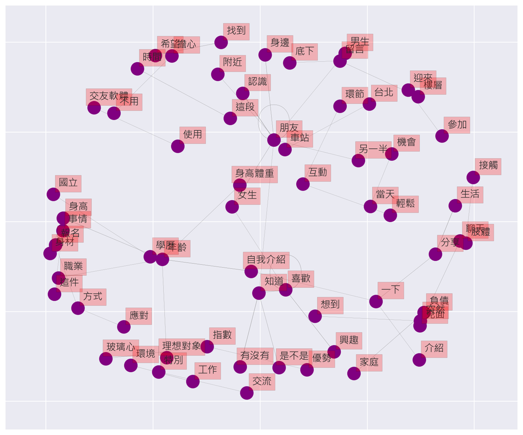

```python
plt.rcParams['font.sans-serif'] = ['Microsoft JhengHei'] # Windows 中文字體
fig, ax = plt.subplots(figsize=(12, 10))

pos = nx.spring_layout(G, k=1.5)

# networks
nx.draw_networkx(G, pos,
                 font_size=16,
                 width=weights,
                 edge_color='grey',
                 node_color='purple',
                 with_labels = False,
                 ax=ax)

# 增加 labels
for key, value in pos.items():
    x, y = value[0]+.07, value[1]+.045
    ax.text(x, y,
            s=key,
            bbox={'facecolor': 'red', 'alpha': 0.25},  # 修正：直接用字典字面量
            horizontalalignment='center', fontsize=13)

plt.show()
```

## Pairwise correlation

```python
data_cor = MetaData.copy()

# 需要改成使用空格連接斷好的詞
data_cor['word'] = data_cor.sentence.apply(getToken).map(' '.join)
data_cor.head(3)
```

|  | system_id | artUrl | artDate | artTitle | artContent | sentence | word |
| --- | --- | --- | --- | --- | --- | --- | --- |
| 0 | 1 | https://www.dcard.tw/f/talk/p/257640963 | 2024-12-31 | 為什麼I人可以用I來當作不社交的藉口 | 如題，MBTI現在很紅，但我很不解有些I人常常碰到需要溝通的事情就說自己是I人，然後就把東西... | 如題現在很紅但我很不解有些人常常碰到需要溝通的事情就說自己是人然後就把東西丟給其他人去處理的... | 現在 很紅 不解 碰到 需要 溝通 事情 東西 丟給 其他人 處理 這種 心態 大學 剛出 ... |
| 1 | 2 | https://www.dcard.tw/f/rainbow/p/257627205 | 2024-12-29 | 這麼剛好！ | 我和她的相遇，在盛夏。\n\n而偏偏，這個夏，颱風特別多，所以緣分恰似撞在了颱風眼上， 悄無... | 我和她的相遇在盛夏而偏偏這個夏颱風特別多所以緣分恰似撞在了颱風眼上悄無聲息襯著神秘讓人難覺往... | 相遇 盛夏 颱風 特別 緣分 颱風眼 悄無聲息 襯著 神秘 難覺 往後 熱烈 記得 相遇 那... |
| 2 | 3 | https://www.dcard.tw/f/mood/p/257619302 | 2024-12-28 | 不回應就是不喜歡 | 雖然知道不管是星座還是MBTI都是參考用，\n但不管過了多久，還是會去翻看有關於你的一切，好... | 雖然知道不管是星座還是都是參考用但不管過了多久還是會去翻看有關於你的一切好想知道你的想法即便... | 知道 星座 參考 過了 多久 翻看 知道 想法 早就 知道 不在意 裝作 忙碌 應對 |

```python
# Bag of Word
# 篩選至少出現在5篇文章以上且詞頻前300的詞彙
vectorizer = CountVectorizer(min_df = 5, max_features = 300)
X = vectorizer.fit_transform(data_cor["word"])
vocabulary = vectorizer.get_feature_names_out()

# 轉成dataframe
DTM_df = pd.DataFrame(columns = vocabulary, data = X.toarray())
DTM_df
```

|  | 一下 | 一位 | 一天 | 一年 | 一次 | 一直 | 一種 | 一點 | 上班 | 不到 | ... | 電影 | 電話 | 需要 | 面試 | 韓國 | 音樂 | 題目 | 願意 | 類型 | 高中 |
| --- | --- | --- | --- | --- | --- | --- | --- | --- | --- | --- | --- | --- | --- | --- | --- | --- | --- | --- | --- | --- | --- |
| 0 | 0 | 0 | 0 | 0 | 0 | 0 | 0 | 0 | 0 | 0 | ... | 0 | 0 | 1 | 0 | 0 | 0 | 0 | 0 | 0 | 0 |
| 1 | 0 | 0 | 0 | 0 | 0 | 1 | 0 | 0 | 0 | 0 | ... | 0 | 0 | 0 | 0 | 0 | 0 | 0 | 0 | 0 | 0 |
| 2 | 0 | 0 | 0 | 0 | 0 | 0 | 0 | 0 | 0 | 0 | ... | 0 | 0 | 0 | 0 | 0 | 0 | 0 | 0 | 0 | 0 |
| 3 | 1 | 0 | 0 | 0 | 0 | 0 | 0 | 0 | 1 | 0 | ... | 0 | 0 | 0 | 0 | 0 | 0 | 0 | 0 | 0 | 0 |
| 4 | 0 | 0 | 0 | 0 | 0 | 0 | 0 | 0 | 0 | 0 | ... | 0 | 0 | 0 | 0 | 0 | 0 | 0 | 0 | 0 | 0 |
| ... | ... | ... | ... | ... | ... | ... | ... | ... | ... | ... | ... | ... | ... | ... | ... | ... | ... | ... | ... | ... | ... |
| 969 | 0 | 0 | 0 | 0 | 0 | 0 | 0 | 0 | 0 | 0 | ... | 1 | 0 | 0 | 0 | 0 | 0 | 0 | 0 | 0 | 0 |
| 970 | 0 | 0 | 0 | 1 | 0 | 0 | 0 | 0 | 1 | 0 | ... | 0 | 0 | 1 | 0 | 0 | 0 | 0 | 0 | 0 | 0 |
| 971 | 0 | 0 | 0 | 0 | 1 | 0 | 0 | 0 | 0 | 0 | ... | 0 | 0 | 0 | 0 | 0 | 0 | 0 | 0 | 0 | 0 |
| 972 | 0 | 0 | 0 | 0 | 0 | 1 | 0 | 0 | 0 | 0 | ... | 0 | 0 | 0 | 0 | 0 | 0 | 0 | 0 | 0 | 0 |
| 973 | 0 | 0 | 0 | 0 | 0 | 0 | 0 | 0 | 0 | 0 | ... | 0 | 0 | 0 | 0 | 0 | 0 | 0 | 0 | 0 | 0 |

974 rows × 300 columns

```python
# 計算詞之間的相關係數
corr_matrix = np.corrcoef(DTM_df.T)

# 轉成dataframe
Cor_df = pd.DataFrame(corr_matrix, index = DTM_df.columns, columns = DTM_df.columns)

Cor_df.insert(0, 'word1', Cor_df.columns)
Cor_df.reset_index(inplace = True, drop = True)

Cor_df
```

|  | word1 | 一下 | 一位 | 一天 | 一年 | 一次 | 一直 | 一種 | 一點 | 上班 | ... | 電影 | 電話 | 需要 | 面試 | 韓國 | 音樂 | 題目 | 願意 | 類型 | 高中 |
| --- | --- | --- | --- | --- | --- | --- | --- | --- | --- | --- | --- | --- | --- | --- | --- | --- | --- | --- | --- | --- | --- |
| 0 | 一下 | 1.000000 | 0.054435 | 0.415935 | 0.096126 | 0.458754 | 0.516153 | 0.174193 | 0.447953 | 0.272915 | ... | 0.147595 | 0.222614 | 0.264469 | -0.002412 | 0.384774 | 0.093580 | 0.166433 | 0.068187 | 0.048179 | 0.096900 |
| 1 | 一位 | 0.054435 | 1.000000 | 0.013104 | 0.209153 | 0.133262 | 0.094571 | 0.024125 | 0.070613 | 0.035344 | ... | 0.011318 | 0.023576 | 0.135119 | 0.143048 | 0.023802 | 0.177189 | 0.059264 | 0.017230 | 0.082453 | 0.072367 |
| 2 | 一天 | 0.415935 | 0.013104 | 1.000000 | 0.175081 | 0.573368 | 0.578965 | 0.135424 | 0.478922 | 0.264226 | ... | 0.211911 | 0.454672 | 0.121871 | 0.027194 | 0.524516 | 0.057765 | 0.153883 | 0.034181 | 0.036738 | 0.050876 |
| 3 | 一年 | 0.096126 | 0.209153 | 0.175081 | 1.000000 | 0.229345 | 0.122422 | 0.065476 | 0.194864 | 0.212207 | ... | 0.116753 | 0.212625 | 0.142773 | 0.048542 | 0.132472 | 0.111079 | 0.117927 | 0.115036 | -0.012821 | 0.033764 |
| 4 | 一次 | 0.458754 | 0.133262 | 0.573368 | 0.229345 | 1.000000 | 0.628200 | 0.141277 | 0.500537 | 0.315101 | ... | 0.220949 | 0.460176 | 0.264722 | 0.061089 | 0.506571 | 0.105454 | 0.092957 | 0.126356 | 0.025493 | 0.109624 |
| ... | ... | ... | ... | ... | ... | ... | ... | ... | ... | ... | ... | ... | ... | ... | ... | ... | ... | ... | ... | ... | ... |
| 295 | 音樂 | 0.093580 | 0.177189 | 0.057765 | 0.111079 | 0.105454 | 0.122029 | 0.023077 | 0.080529 | 0.033020 | ... | 0.083016 | 0.098873 | 0.040862 | -0.000617 | 0.115465 | 1.000000 | 0.034253 | 0.132368 | 0.074564 | 0.065157 |
| 296 | 題目 | 0.166433 | 0.059264 | 0.153883 | 0.117927 | 0.092957 | 0.061646 | 0.273884 | 0.157981 | 0.001307 | ... | -0.006596 | 0.059196 | 0.165612 | 0.087719 | 0.009978 | 0.034253 | 1.000000 | 0.059960 | 0.042215 | -0.013843 |
| 297 | 願意 | 0.068187 | 0.017230 | 0.034181 | 0.115036 | 0.126356 | 0.064127 | 0.108783 | 0.207062 | 0.167814 | ... | 0.239605 | 0.015591 | 0.259736 | 0.018939 | -0.003845 | 0.132368 | 0.059960 | 1.000000 | 0.115599 | 0.047502 |
| 298 | 類型 | 0.048179 | 0.082453 | 0.036738 | -0.012821 | 0.025493 | 0.014556 | 0.182527 | 0.089159 | 0.025070 | ... | 0.005250 | -0.014282 | 0.069738 | -0.007687 | 0.000595 | 0.074564 | 0.042215 | 0.115599 | 1.000000 | 0.024406 |
| 299 | 高中 | 0.096900 | 0.072367 | 0.050876 | 0.033764 | 0.109624 | 0.097789 | 0.121416 | 0.107378 | 0.158331 | ... | 0.016000 | 0.055400 | 0.069762 | 0.003097 | 0.026766 | 0.065157 | -0.013843 | 0.047502 | 0.024406 | 1.000000 |

300 rows × 301 columns

```python
word_cor_df = Cor_df.melt(id_vars = 'word1', var_name = 'word2', value_name = 'cor')

# 去除兩個詞相同的情況
word_cor_df = word_cor_df[word_cor_df["word1"] != word_cor_df["word2"]]

word_cor_df.sort_values('cor', ascending=False).head(10)
```

|  | word1 | word2 | cor |
| --- | --- | --- | --- |
| 88264 | 哈哈哈 | 韓國 | 0.928859 |
| 19494 | 韓國 | 哈哈哈 | 0.928859 |
| 50832 | 房間 | 本來 | 0.919420 |
| 39769 | 本來 | 房間 | 0.919420 |
| 19420 | 突然 | 哈哈哈 | 0.911755 |
| 66064 | 哈哈哈 | 突然 | 0.911755 |
| 3664 | 哈哈哈 | 不想 | 0.908269 |
| 19212 | 不想 | 哈哈哈 | 0.908269 |
| 9064 | 哈哈哈 | 今天 | 0.893808 |
| 19230 | 今天 | 哈哈哈 | 0.893808 |

### 和 「生活」, 「工作」 相關性最高的 10 個詞彙

```python
ice_sum = word_cor_df[(word_cor_df["word1"] == "生活")].sort_values(by = ['cor'], ascending = False).head(10)
taste_sum = word_cor_df[(word_cor_df["word1"] == "工作")].sort_values(by = ['cor'], ascending = False).head(10)
```

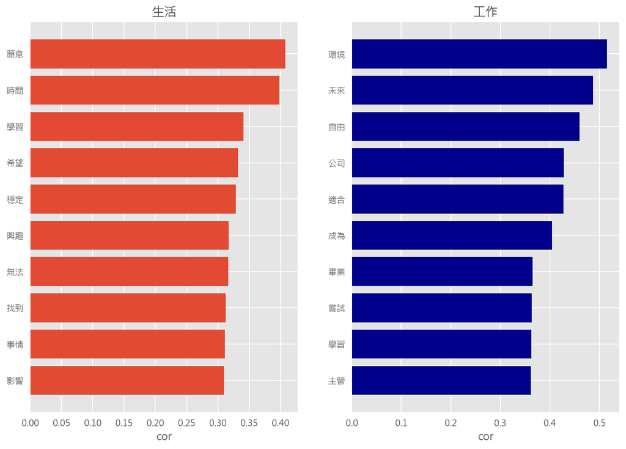

```python
plt.rcParams['font.sans-serif'] = ['Microsoft JhengHei'] # Windows 中文字體
plt.figure(figsize=(12,8))   # 顯示圖框架大小 (寬,高)
plt.style.use("ggplot")     # 使用ggplot主題樣式

plt.subplot(121)
plt.title('生活')
plt.xlabel('cor')
plt.barh(ice_sum['word2'],ice_sum['cor'])
plt.gca().invert_yaxis()

plt.subplot(122)
plt.title('工作')
plt.xlabel('cor')
plt.barh(taste_sum['word2'],taste_sum['cor'],color="darkblue")
plt.gca().invert_yaxis()

plt.show()
```

### 使用詞彙關係圖畫出以詞頻前30為節點且相關性高於0.3的組合

```python
# 透過DTM找出詞頻前60高的詞彙
most_freq_df = DTM_df.sum().sort_values(ascending=False).head(30).reset_index().rename(columns={'index':'word', 0:'count'})

most_freq_word = most_freq_df['word'].tolist()
```

```python
# 保留存在詞頻前60高之詞彙的組合
filtered_df = word_cor_df[(word_cor_df['word1'].isin(most_freq_word)) & (word_cor_df['word2'].isin(most_freq_word))]

# 篩選出相關係數大於0.3的組合
filtered_df = filtered_df[filtered_df['cor'] > 0.3]
filtered_df.reset_index(inplace=True, drop=True)
filtered_df
```

|  | word1 | word2 | cor |
| --- | --- | --- | --- |
| 0 | 一直 | 一下 | 0.516153 |
| 1 | 之後 | 一下 | 0.599577 |
| 2 | 事情 | 一下 | 0.369046 |
| 3 | 喜歡 | 一下 | 0.408604 |
| 4 | 好像 | 一下 | 0.554976 |
| ... | ... | ... | ... |
| 349 | 問題 | 需要 | 0.342283 |
| 350 | 工作 | 需要 | 0.304672 |
| 351 | 時間 | 需要 | 0.482182 |
| 352 | 最後 | 需要 | 0.312610 |
| 353 | 知道 | 需要 | 0.313867 |

354 rows × 3 columns

```python
# Create network plot
g = nx.Graph()

# 建立 nodes 間的連結
for i in range(len(filtered_df)):
    g.add_edge(filtered_df["word1"][i], filtered_df["word2"][i], weight=filtered_df["cor"][i])

# 取得edge權重
weights = [w[2]['weight']*5 for w in  g.edges(data=True)]
```

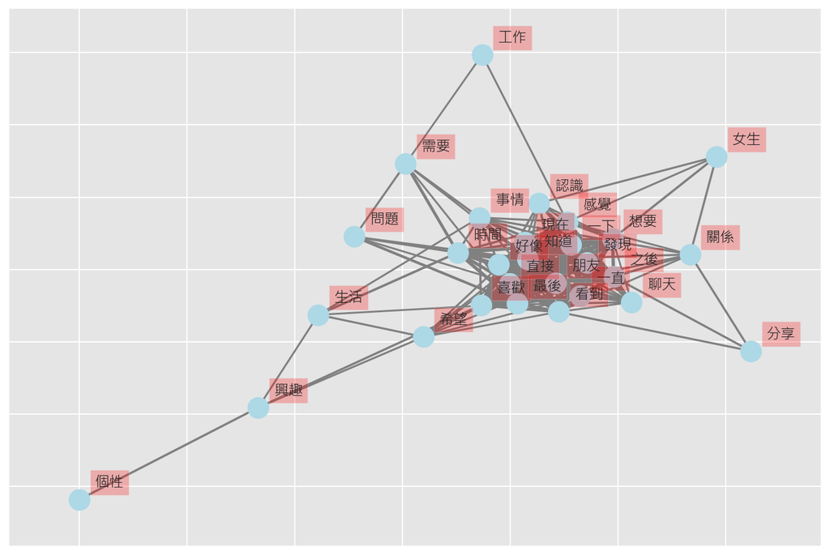

```python
fig, ax = plt.subplots(figsize=(12, 8))
plt.rcParams['font.sans-serif'] = ['Microsoft JhengHei'] # Windows 中文字體

pos = nx.spring_layout(g, k=0.3)

# networks
nx.draw_networkx(g, pos,
                 font_size=16,
                 width=weights,
                 edge_color='grey',
                 node_color='lightblue',
                 with_labels = False,
                 ax=ax)

# 增加 labels
for key, value in pos.items():
    x, y = value[0]+.07, value[1]+.045
    ax.text(x, y,
            s=key,
            bbox={'facecolor': 'red', 'alpha': 0.25},  # 修正：直接用字典字面量
            horizontalalignment='center', fontsize=12)

plt.show()
```

## 計算文章相似度

以TF-IDF的結果當作文章的向量，計算 Cosine Similarity 找出相似的文章

```python
data_cos = data_cor.copy()
data_cos.head(3)
```

|  | system_id | artUrl | artDate | artTitle | artContent | sentence | word |
| --- | --- | --- | --- | --- | --- | --- | --- |
| 0 | 1 | https://www.dcard.tw/f/talk/p/257640963 | 2024-12-31 | 為什麼I人可以用I來當作不社交的藉口 | 如題，MBTI現在很紅，但我很不解有些I人常常碰到需要溝通的事情就說自己是I人，然後就把東西... | 如題現在很紅但我很不解有些人常常碰到需要溝通的事情就說自己是人然後就把東西丟給其他人去處理的... | 現在 很紅 不解 碰到 需要 溝通 事情 東西 丟給 其他人 處理 這種 心態 大學 剛出 ... |
| 1 | 2 | https://www.dcard.tw/f/rainbow/p/257627205 | 2024-12-29 | 這麼剛好！ | 我和她的相遇，在盛夏。\n\n而偏偏，這個夏，颱風特別多，所以緣分恰似撞在了颱風眼上， 悄無... | 我和她的相遇在盛夏而偏偏這個夏颱風特別多所以緣分恰似撞在了颱風眼上悄無聲息襯著神秘讓人難覺往... | 相遇 盛夏 颱風 特別 緣分 颱風眼 悄無聲息 襯著 神秘 難覺 往後 熱烈 記得 相遇 那... |
| 2 | 3 | https://www.dcard.tw/f/mood/p/257619302 | 2024-12-28 | 不回應就是不喜歡 | 雖然知道不管是星座還是MBTI都是參考用，\n但不管過了多久，還是會去翻看有關於你的一切，好... | 雖然知道不管是星座還是都是參考用但不管過了多久還是會去翻看有關於你的一切好想知道你的想法即便... | 知道 星座 參考 過了 多久 翻看 知道 想法 早就 知道 不在意 裝作 忙碌 應對 |

```python
transformer = TfidfTransformer()
print(transformer)
# 將詞頻矩陣X統計成TF-IDF值
tfidf = transformer.fit_transform(X)

# 轉成dataframe
TFIDF_df = pd.DataFrame(columns = vocabulary, data = tfidf.toarray())
TFIDF_df
```

```
TfidfTransformer()
```

|  | 一下 | 一位 | 一天 | 一年 | 一次 | 一直 | 一種 | 一點 | 上班 | 不到 | ... | 電影 | 電話 | 需要 | 面試 | 韓國 | 音樂 | 題目 | 願意 | 類型 | 高中 |
| --- | --- | --- | --- | --- | --- | --- | --- | --- | --- | --- | --- | --- | --- | --- | --- | --- | --- | --- | --- | --- | --- |
| 0 | 0.000000 | 0.0 | 0.0 | 0.000000 | 0.000000 | 0.000000 | 0.0 | 0.0 | 0.000000 | 0.0 | ... | 0.00000 | 0.0 | 0.118694 | 0.0 | 0.0 | 0.0 | 0.0 | 0.0 | 0.0 | 0.0 |
| 1 | 0.000000 | 0.0 | 0.0 | 0.000000 | 0.000000 | 0.135322 | 0.0 | 0.0 | 0.000000 | 0.0 | ... | 0.00000 | 0.0 | 0.000000 | 0.0 | 0.0 | 0.0 | 0.0 | 0.0 | 0.0 | 0.0 |
| 2 | 0.000000 | 0.0 | 0.0 | 0.000000 | 0.000000 | 0.000000 | 0.0 | 0.0 | 0.000000 | 0.0 | ... | 0.00000 | 0.0 | 0.000000 | 0.0 | 0.0 | 0.0 | 0.0 | 0.0 | 0.0 | 0.0 |
| 3 | 0.103262 | 0.0 | 0.0 | 0.000000 | 0.000000 | 0.000000 | 0.0 | 0.0 | 0.144937 | 0.0 | ... | 0.00000 | 0.0 | 0.000000 | 0.0 | 0.0 | 0.0 | 0.0 | 0.0 | 0.0 | 0.0 |
| 4 | 0.000000 | 0.0 | 0.0 | 0.000000 | 0.000000 | 0.000000 | 0.0 | 0.0 | 0.000000 | 0.0 | ... | 0.00000 | 0.0 | 0.000000 | 0.0 | 0.0 | 0.0 | 0.0 | 0.0 | 0.0 | 0.0 |
| ... | ... | ... | ... | ... | ... | ... | ... | ... | ... | ... | ... | ... | ... | ... | ... | ... | ... | ... | ... | ... | ... |
| 969 | 0.000000 | 0.0 | 0.0 | 0.000000 | 0.000000 | 0.000000 | 0.0 | 0.0 | 0.000000 | 0.0 | ... | 0.18771 | 0.0 | 0.000000 | 0.0 | 0.0 | 0.0 | 0.0 | 0.0 | 0.0 | 0.0 |
| 970 | 0.000000 | 0.0 | 0.0 | 0.128627 | 0.000000 | 0.000000 | 0.0 | 0.0 | 0.128627 | 0.0 | ... | 0.00000 | 0.0 | 0.095226 | 0.0 | 0.0 | 0.0 | 0.0 | 0.0 | 0.0 | 0.0 |
| 971 | 0.000000 | 0.0 | 0.0 | 0.000000 | 0.201068 | 0.000000 | 0.0 | 0.0 | 0.000000 | 0.0 | ... | 0.00000 | 0.0 | 0.000000 | 0.0 | 0.0 | 0.0 | 0.0 | 0.0 | 0.0 | 0.0 |
| 972 | 0.000000 | 0.0 | 0.0 | 0.000000 | 0.000000 | 0.378569 | 0.0 | 0.0 | 0.000000 | 0.0 | ... | 0.00000 | 0.0 | 0.000000 | 0.0 | 0.0 | 0.0 | 0.0 | 0.0 | 0.0 | 0.0 |
| 973 | 0.000000 | 0.0 | 0.0 | 0.000000 | 0.000000 | 0.000000 | 0.0 | 0.0 | 0.000000 | 0.0 | ... | 0.00000 | 0.0 | 0.000000 | 0.0 | 0.0 | 0.0 | 0.0 | 0.0 | 0.0 | 0.0 |

974 rows × 300 columns

計算文章間的cosine similarity

```python
cosine_matrix = cosine_similarity(tfidf.toarray(), tfidf.toarray())
```

檢視與第一篇文章相似的文章

```python
cos_df = pd.DataFrame(cosine_matrix[0], columns = ['cos_similarity'])
cos_df
```

|  | cos_similarity |
| --- | --- |
| 0 | 1.000000 |
| 1 | 0.000000 |
| 2 | 0.000000 |
| 3 | 0.036324 |
| 4 | 0.021430 |
| ... | ... |
| 969 | 0.021566 |
| 970 | 0.031124 |
| 971 | 0.059488 |
| 972 | 0.239825 |
| 973 | 0.044754 |

974 rows × 1 columns

```python
cos_df = cos_df.merge(data_cos, how = 'left', left_index=True, right_index=True)
cos_df.loc[:,["cos_similarity", "artTitle", "artUrl"]].sort_values(by=['cos_similarity'], ascending=False).head(5)
```

|  | cos_similarity | artTitle | artUrl |
| --- | --- | --- | --- |
| 0 | 1.000000 | 為什麼I人可以用I來當作不社交的藉口 | https://www.dcard.tw/f/talk/p/257640963 |
| 708 | 0.405927 | #閒聊 突破職場溝通困難的五大關鍵！ | https://www.dcard.tw/f/job/p/254718430 |
| 724 | 0.395402 | 跟高中時期的男神在一起 MBTI | https://www.dcard.tw/f/rainbow/p/254677475 |
| 801 | 0.374818 | #請益 有人會用對方的 MBTI 決定如何與對方溝通嗎？ | https://www.dcard.tw/f/job/p/258097080 |
| 410 | 0.355889 | I人不代表不會社交好嗎 | https://www.dcard.tw/f/talk/p/255934213 |

檢視與第14篇文章相似的文章

```python
cos_df_14 = pd.DataFrame(cosine_matrix[14], columns=['cos_similarity'])

cos_df_14 = cos_df_14.merge(data_cos, how = 'left', left_index=True, right_index=True)
cos_df_14.loc[:,["cos_similarity", "artTitle", "artUrl"]].sort_values(by=['cos_similarity'], ascending=False).head(5)
```

|  | cos_similarity | artTitle | artUrl |
| --- | --- | --- | --- |
| 14 | 1.000000 | INTJ真的很稀有嗎🤔 | https://www.dcard.tw/f/mood/p/257494317 |
| 282 | 0.408574 | 遇到災難級別迴避型，媽的有夠消耗 | https://www.dcard.tw/f/relationship/p/256996653 |
| 188 | 0.389762 | #問題 想問牡羊男這樣是喜歡我嗎? | https://www.dcard.tw/f/horoscopes/p/257040943 |
| 377 | 0.362468 | 閒暇時間大家喜歡做什麼？ | https://www.dcard.tw/f/talk/p/255728647 |
| 846 | 0.358063 | #問題 當男朋友的第一任女友要怎麼相處 | https://www.dcard.tw/f/relationship/p/257681017 |

## 分析主題

將Dcard數個版別的文章合起來，訓練模型能預測男女生發言，再用分類模型進行男女生的分類。

```python
import re
from pprint import pprint
import seaborn as sns
from sklearn.model_selection import train_test_split, cross_validate, cross_val_predict, KFold
from sklearn.metrics import (
    confusion_matrix,
    classification_report,
    roc_curve,
    auc,
    precision_recall_curve,
    RocCurveDisplay
)
from sklearn.feature_extraction.text import TfidfVectorizer, CountVectorizer
from sklearn.preprocessing import LabelBinarizer
from sklearn.linear_model import LogisticRegression
from sklearn.naive_bayes import GaussianNB
from sklearn.tree import DecisionTreeClassifier, plot_tree
from sklearn.ensemble import RandomForestClassifier
from sklearn import svm
```

```python
# 匯入資料
MBTI_FM = pd.read_csv("raw_data\dataset_mbti.csv")

# 過濾 NaN 的資料
MBTI_FM = MBTI_FM.dropna(subset=['artTitle', 'artContent'])

# 移除網址格式
MBTI_FM["artContent"] = MBTI_FM.artContent.apply(
    lambda x: re.sub(r"(http|https)://[^\s]*", "", x)
)
MBTI_FM["artTitle"] = MBTI_FM["artTitle"].apply(
    lambda x: re.sub(r"(http|https)://[^\s]*", "", x)
)

# 清理多餘空格並保留中文字符（允許標點符號以利分詞）
MBTI_FM["artContent"] = MBTI_FM.artContent.apply(
    lambda x: re.sub(r'\s+', ' ', x).strip()  # 合併多餘空格並移除首尾空格
)
MBTI_FM["artTitle"] = MBTI_FM["artTitle"].apply(
    lambda x: re.sub(r'\s+', ' ', x).strip()
)

# 僅保留中文字符和常見標點符號
MBTI_FM["artContent"] = MBTI_FM.artContent.apply(
    lambda x: re.sub(r'[^\u4e00-\u9fa5，。！？]', '', x)
)
MBTI_FM["artTitle"] = MBTI_FM["artTitle"].apply(
    lambda x: re.sub(r'[^\u4e00-\u9fa5，。！？]', '', x)
)

# 合併標題和內容
MBTI_FM["content"] = MBTI_FM["artTitle"] + MBTI_FM["artContent"]

# 過濾空內容或過短內容（例如少於10個字符）
MBTI_FM = MBTI_FM[MBTI_FM["content"].str.len() >= 10]

# 保留所需欄位
MBTI_FM = MBTI_FM[["content", "artUrl", "gender"]]

# 看看有幾篇文章
print(f"total docs: {MBTI_FM.shape[0]} 篇")

# 顯示前三筆資料
MBTI_FM.head(3)
```

```
total docs: 930 篇
```

|  | content | artUrl | gender |
| --- | --- | --- | --- |
| 0 | 為什麼人可以用來當作不社交的藉口如題，現在很紅，但我很不解有些人常常碰到需要溝通的事情就說自... | https://www.dcard.tw/f/talk/p/257640963 | M |
| 1 | 這麼剛好！我和她的相遇，在盛夏。而偏偏，這個夏，颱風特別多，所以緣分恰似撞在了颱風眼上，悄無... | https://www.dcard.tw/f/rainbow/p/257627205 | F |
| 2 | 不回應就是不喜歡雖然知道不管是星座還是都是參考用，但不管過了多久，還是會去翻看有關於你的一切... | https://www.dcard.tw/f/mood/p/257619302 | F |

```python
# 設定繁體中文詞庫
jieba.set_dictionary("dict\dict.txt.big")

# 新增stopwords
# jieba.analyse.set_stop_words('./dict/stop_words.txt') #jieba.analyse.extract_tags才會作用
with open("dict\stop_words.txt", encoding="utf-8") as f:
    stopWords = [line.strip() for line in f.readlines()]
```

```python
# 設定斷詞 function
def getToken(row):
    seg_list = jieba.cut(row, cut_all=False)
    seg_list = [
        w for w in seg_list if w not in stopWords and len(w) > 1
    ]  # 篩選掉停用字與字元數大於1的詞彙
    return seg_list
```

```python
MBTI_FM = MBTI_FM[MBTI_FM["gender"] != "D"]
MBTI_FM["words"] = MBTI_FM["content"].apply(getToken).map(" ".join)
MBTI_FM.head()
```

```
Building prefix dict from c:\Users\Rosie\Documents\研究所\社群媒體分析\SMA_finalProject\dict\dict.txt.big ...
Loading model from cache C:\Users\Rosie\AppData\Local\Temp\jieba.u9e434e2756c7e53fdc471cb01160378f.cache
Loading model cost 0.500 seconds.
Prefix dict has been built successfully.
```

|  | content | artUrl | gender | words |
| --- | --- | --- | --- | --- |
| 0 | 為什麼人可以用來當作不社交的藉口如題，現在很紅，但我很不解有些人常常碰到需要溝通的事情就說自... | https://www.dcard.tw/f/talk/p/257640963 | M | 用來 當作 社交 藉口 現在 很紅 不解 碰到 需要 溝通 事情 東西 丟給 其他人 處理 ... |
| 1 | 這麼剛好！我和她的相遇，在盛夏。而偏偏，這個夏，颱風特別多，所以緣分恰似撞在了颱風眼上，悄無... | https://www.dcard.tw/f/rainbow/p/257627205 | F | 相遇 盛夏 颱風 特別 緣分 颱風眼 悄無聲息 襯著 神秘 難覺 往後 熱烈 記得 相遇 那... |
| 2 | 不回應就是不喜歡雖然知道不管是星座還是都是參考用，但不管過了多久，還是會去翻看有關於你的一切... | https://www.dcard.tw/f/mood/p/257619302 | F | 回應 喜歡 知道 星座 參考 過了 多久 翻看 知道 想法 早就 知道 不在意 裝作 忙碌 回應 |
| 3 | 不知道姐姐對我有沒有好感在迪卡上認識了一個姐姐到今天已經連續聊一個禮拜因為我想說慢慢來所以聊... | https://www.dcard.tw/f/rainbow/p/257635779 | F | 知道 姐姐 有沒有 好感 迪卡上 認識 姐姐 今天 已經 連續 禮拜 慢慢來 主動 擔心 禮... |
| 4 | 不去要就很膽小？？？今天剛好悠閒來測然後，我測試出來的是，我就把這個測試結果放在便利貼裡面，... | https://www.dcard.tw/f/mood/p/257603606 | F | 不去 膽小 今天 悠閒 來測 測試 測試 放在 便利 貼裡面 晚上 朋友 留言 便利 真的 ... |

### 2.3 資料集基本檢視

```python
print(f"total posts: {len(MBTI_FM['artUrl'].unique())}")
print(f"category: \n{MBTI_FM['gender'].value_counts()}")
```

```
total posts: 921
category:
gender
F    588
M    333
Name: count, dtype: int64
```

## 3. 分類模型的訓練流程

### 3.1 根據7:3的比例切分資料集

利用 sklearn 中的 train_test_split 函數將 `raw_data` 隨機切成 7:3，設置 random_state 讓每次切分的結果一致。`y_train`和`y_test`分別為訓練資料和測試資料的預測目標。

```python
data = MBTI_FM
X = data["words"]
y = data["gender"]

# 把整個資料集七三切
X_train, X_test, y_train, y_test = train_test_split(
    X, y, test_size=0.3, random_state=777
)

print(X_train.head())
print(y_train.head())
```

```
118    迷戀 公司 前輩 文長 這篇 小妹妹 心情 抒發 不用 認真 社會工作 大學生 累積 幾個 ...
527                          裡的型 知道 裡的 一些 分布 女生 女生 男生 男生
159    旅伴 東京 知道 版上 有沒有 三天 東京 尋找 一起 行程 旅伴 拍照 陪伴 女生 排斥 ...
298    積極 追求 小妹 年歲 談過 一段 戀愛 適合 共同 目標 分開 一直 追求 愛情 目前 身...
152    單求 認領 以下 自我介紹 年齡 大學生 個性 社恐 一枚 還在 練習 聊天 訊息 給我 一...
Name: words, dtype: object
118    F
527    F
159    F
298    F
152    F
Name: gender, dtype: object
```

```python
# 看一下各個資料集切分的比例，應該要一致
print(
    f"raw data percentage :\n{data['gender'].value_counts(normalize=True) * 100}"
)
print(f"\ntrain percentage :\n{y_train.value_counts(normalize=True) * 100}")
print(f"\ntest percentage :\n{y_test.value_counts(normalize=True) * 100}")
```

```
raw data percentage :
gender
F    63.843648
M    36.156352
Name: proportion, dtype: float64

train percentage :
gender
F    64.440994
M    35.559006
Name: proportion, dtype: float64

test percentage :
gender
F    62.454874
M    37.545126
Name: proportion, dtype: float64
```

```python
vectorizer = CountVectorizer(max_features=1000)
print(vectorizer)

X_train.head()
```

```
CountVectorizer(max_features=1000)
```

```
118    迷戀 公司 前輩 文長 這篇 小妹妹 心情 抒發 不用 認真 社會工作 大學生 累積 幾個 ...
527                          裡的型 知道 裡的 一些 分布 女生 女生 男生 男生
159    旅伴 東京 知道 版上 有沒有 三天 東京 尋找 一起 行程 旅伴 拍照 陪伴 女生 排斥 ...
298    積極 追求 小妹 年歲 談過 一段 戀愛 適合 共同 目標 分開 一直 追求 愛情 目前 身...
152    單求 認領 以下 自我介紹 年齡 大學生 個性 社恐 一枚 還在 練習 聊天 訊息 給我 一...
Name: words, dtype: object
```

```python
vec_train = vectorizer.fit_transform(X_train)
vocabulary = vectorizer.get_feature_names_out()

Count_df = pd.DataFrame(columns = vocabulary, data = vec_train.toarray())
Count_df
```

|  | 一下 | 一些 | 一件 | 一份 | 一位 | 一個月 | 一句 | 一堆 | 一天 | 一定 | ... | 食物 | 飲料 | 養活 | 餐廳 | 香港 | 體驗 | 高中 | 麻煩 | 默默 | 鼓勵 |
| --- | --- | --- | --- | --- | --- | --- | --- | --- | --- | --- | --- | --- | --- | --- | --- | --- | --- | --- | --- | --- | --- |
| 0 | 0 | 1 | 1 | 1 | 0 | 0 | 0 | 0 | 0 | 0 | ... | 0 | 0 | 0 | 0 | 0 | 0 | 0 | 0 | 1 | 0 |
| 1 | 0 | 1 | 0 | 0 | 0 | 0 | 0 | 0 | 0 | 0 | ... | 0 | 0 | 0 | 0 | 0 | 0 | 0 | 0 | 0 | 0 |
| 2 | 1 | 0 | 0 | 0 | 0 | 0 | 0 | 0 | 1 | 0 | ... | 0 | 0 | 0 | 1 | 0 | 0 | 0 | 0 | 0 | 0 |
| 3 | 0 | 0 | 0 | 0 | 0 | 0 | 0 | 0 | 0 | 0 | ... | 0 | 0 | 0 | 0 | 0 | 0 | 0 | 0 | 0 | 0 |
| 4 | 0 | 0 | 0 | 0 | 0 | 0 | 0 | 0 | 0 | 1 | ... | 0 | 0 | 0 | 0 | 0 | 0 | 0 | 0 | 0 | 0 |
| ... | ... | ... | ... | ... | ... | ... | ... | ... | ... | ... | ... | ... | ... | ... | ... | ... | ... | ... | ... | ... | ... |
| 639 | 0 | 0 | 0 | 0 | 0 | 0 | 0 | 0 | 0 | 0 | ... | 0 | 0 | 0 | 0 | 0 | 0 | 0 | 0 | 0 | 0 |
| 640 | 0 | 1 | 0 | 0 | 0 | 0 | 0 | 0 | 0 | 0 | ... | 0 | 0 | 0 | 0 | 0 | 0 | 0 | 0 | 0 | 0 |
| 641 | 0 | 0 | 0 | 0 | 0 | 0 | 0 | 0 | 0 | 0 | ... | 0 | 0 | 0 | 0 | 0 | 0 | 0 | 0 | 0 | 0 |
| 642 | 0 | 2 | 0 | 0 | 0 | 0 | 1 | 0 | 0 | 0 | ... | 0 | 0 | 0 | 0 | 0 | 0 | 0 | 0 | 0 | 0 |
| 643 | 1 | 0 | 0 | 0 | 0 | 0 | 0 | 0 | 0 | 0 | ... | 0 | 0 | 0 | 0 | 0 | 0 | 0 | 0 | 0 | 0 |

644 rows × 1000 columns

```python
# 不需重新 `fit()` data，因前面已經 `fit()` 過了
# 只需將測試數據使用之前訓練好的 vectorizer 轉換為相同的特徵表示形式，而不需要重新fit。
# 如果對測試數據再次 fit vectorizer，可能會導致使用了測試數據的信息，進而導致模型的不穩定性和過度擬合的問題。
vec_test = vectorizer.transform(X_test)
print(vec_train.shape)
print(vec_test.shape)
```

```
(644, 1000)
(277, 1000)
```

```python
# 建立分類器模型
clf = LogisticRegression()
clf.fit(vec_train, y_train)
clf
```

```
LogisticRegression()
```

```python
clf.classes_
```

```
array(['F', 'M'], dtype=object)
```

使用train set訓練完後，用測試集試試看模型的分類結果

```python
y_pred = clf.predict(vec_test)
y_pred_proba = clf.predict_proba(vec_test)
print(y_pred[:10])
```

```
['F' 'F' 'F' 'F' 'F' 'M' 'F' 'F' 'M' 'F']
```

觀察看看模型輸出的類別機率

```python
print(y_pred_proba.shape)
y_pred_proba[0,:]
```

```
(277, 2)
```

```
array([0.99813607, 0.00186393])
```

### 模型評估

```python
## Accuracy, Precision, Recall, F1-score
print(classification_report(y_test, y_pred))
```

```
              precision    recall  f1-score   support

           F       0.70      0.82      0.75       173
           M       0.58      0.40      0.47       104

    accuracy                           0.66       277
   macro avg       0.64      0.61      0.61       277
weighted avg       0.65      0.66      0.65       277
```

- 混淆矩陣（Confusion Matrix）是一種評估分類模型性能的工具，特別適用於分類問題。它以矩陣形式呈現模型的預測結果與實際標籤之間的對比，幫助識別模型在各類別上的表現。

```python
# 根據實際出現的類別修正 classes
actual_classes = np.unique(y_test)  # 或者使用 np.unique(y_pred)，根據需求
cm = confusion_matrix(y_test, y_pred)
print("修正後的類別標籤：", actual_classes)
```

```
修正後的類別標籤： ['F' 'M']
```

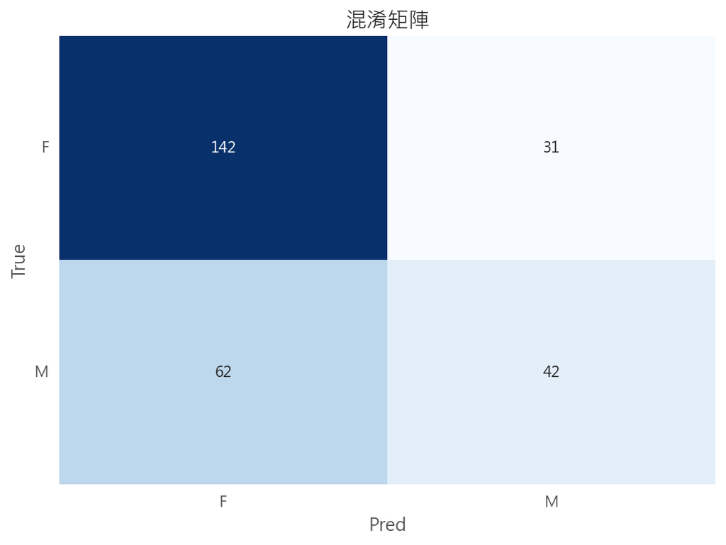

```python
# 繪製混淆矩陣
fig, ax = plt.subplots()
sns.heatmap(cm, annot=True, fmt="d", ax=ax, cmap=plt.cm.Blues, cbar=False)
ax.set(
    xlabel="Pred",
    ylabel="True",
    xticklabels=actual_classes,
    yticklabels=actual_classes,
    title="混淆矩陣"
)
plt.yticks(rotation=0)
plt.savefig('confusion_matrix.png')
```

### TF-IDF

改試試看使用 TF-IDF 的 DTM 來代表文章，訓練分類模型的效果

```python
vectorizer = TfidfVectorizer(max_features=1000)
vec_train = vectorizer.fit_transform(X_train)
vec_test = vectorizer.transform(X_test)
vocabulary = vectorizer.get_feature_names_out()

tfidf_df = pd.DataFrame(columns = vocabulary, data = vec_train.toarray())
tfidf_df
```

|  | 一下 | 一些 | 一件 | 一份 | 一位 | 一個月 | 一句 | 一堆 | 一天 | 一定 | ... | 食物 | 飲料 | 養活 | 餐廳 | 香港 | 體驗 | 高中 | 麻煩 | 默默 | 鼓勵 |
| --- | --- | --- | --- | --- | --- | --- | --- | --- | --- | --- | --- | --- | --- | --- | --- | --- | --- | --- | --- | --- | --- |
| 0 | 0.000000 | 0.035192 | 0.058106 | 0.063752 | 0.0 | 0.0 | 0.000000 | 0.0 | 0.000000 | 0.000000 | ... | 0.0 | 0.0 | 0.0 | 0.000000 | 0.0 | 0.0 | 0.0 | 0.0 | 0.061605 | 0.0 |
| 1 | 0.000000 | 0.255903 | 0.000000 | 0.000000 | 0.0 | 0.0 | 0.000000 | 0.0 | 0.000000 | 0.000000 | ... | 0.0 | 0.0 | 0.0 | 0.000000 | 0.0 | 0.0 | 0.0 | 0.0 | 0.000000 | 0.0 |
| 2 | 0.070716 | 0.000000 | 0.000000 | 0.000000 | 0.0 | 0.0 | 0.000000 | 0.0 | 0.100639 | 0.000000 | ... | 0.0 | 0.0 | 0.0 | 0.117008 | 0.0 | 0.0 | 0.0 | 0.0 | 0.000000 | 0.0 |
| 3 | 0.000000 | 0.000000 | 0.000000 | 0.000000 | 0.0 | 0.0 | 0.000000 | 0.0 | 0.000000 | 0.000000 | ... | 0.0 | 0.0 | 0.0 | 0.000000 | 0.0 | 0.0 | 0.0 | 0.0 | 0.000000 | 0.0 |
| 4 | 0.000000 | 0.000000 | 0.000000 | 0.000000 | 0.0 | 0.0 | 0.000000 | 0.0 | 0.000000 | 0.130831 | ... | 0.0 | 0.0 | 0.0 | 0.000000 | 0.0 | 0.0 | 0.0 | 0.0 | 0.000000 | 0.0 |
| ... | ... | ... | ... | ... | ... | ... | ... | ... | ... | ... | ... | ... | ... | ... | ... | ... | ... | ... | ... | ... | ... |
| 639 | 0.000000 | 0.000000 | 0.000000 | 0.000000 | 0.0 | 0.0 | 0.000000 | 0.0 | 0.000000 | 0.000000 | ... | 0.0 | 0.0 | 0.0 | 0.000000 | 0.0 | 0.0 | 0.0 | 0.0 | 0.000000 | 0.0 |
| 640 | 0.000000 | 0.049892 | 0.000000 | 0.000000 | 0.0 | 0.0 | 0.000000 | 0.0 | 0.000000 | 0.000000 | ... | 0.0 | 0.0 | 0.0 | 0.000000 | 0.0 | 0.0 | 0.0 | 0.0 | 0.000000 | 0.0 |
| 641 | 0.000000 | 0.000000 | 0.000000 | 0.000000 | 0.0 | 0.0 | 0.000000 | 0.0 | 0.000000 | 0.000000 | ... | 0.0 | 0.0 | 0.0 | 0.000000 | 0.0 | 0.0 | 0.0 | 0.0 | 0.000000 | 0.0 |
| 642 | 0.000000 | 0.077708 | 0.000000 | 0.000000 | 0.0 | 0.0 | 0.062029 | 0.0 | 0.000000 | 0.000000 | ... | 0.0 | 0.0 | 0.0 | 0.000000 | 0.0 | 0.0 | 0.0 | 0.0 | 0.000000 | 0.0 |
| 643 | 0.423388 | 0.000000 | 0.000000 | 0.000000 | 0.0 | 0.0 | 0.000000 | 0.0 | 0.000000 | 0.000000 | ... | 0.0 | 0.0 | 0.0 | 0.000000 | 0.0 | 0.0 | 0.0 | 0.0 | 0.000000 | 0.0 |

644 rows × 1000 columns

```python
clf.fit(vec_train, y_train)
y_pred = clf.predict(vec_test)
y_pred_proba = clf.predict_proba(vec_test)

# results
## Accuracy, Precision, Recall, F1-score
print(classification_report(y_test, y_pred))
```

```
              precision    recall  f1-score   support

           F       0.67      0.91      0.77       173
           M       0.63      0.26      0.37       104

    accuracy                           0.66       277
   macro avg       0.65      0.58      0.57       277
weighted avg       0.65      0.66      0.62       277
```

[output not shown]

### Cross-Validation(CV)

在機器學習中，是一個很常用來讓模型評估能夠得到更穩定的數值的手法。

```python
X_train_filtered = X_train[mask]
y_train_filtered = y_train[mask]

vec_train = TfidfVectorizer(max_features=1000).fit_transform(X_train_filtered)
clf = LogisticRegression()

scores = cross_validate(
    clf, vec_train, y_train_filtered, cv=5,
    scoring=("f1_macro", "recall_macro", "precision_macro"),
    return_estimator=True
)
pprint(scores)
```

```
{'estimator': [LogisticRegression(),
               LogisticRegression(),
               LogisticRegression(),
               LogisticRegression(),
               LogisticRegression()],
 'fit_time': array([0.00300002, 0.00300026, 0.00299883, 0.00199771, 0.00300002]),
 'score_time': array([0.00199986, 0.002002  , 0.00200152, 0.00199986, 0.00200009]),
 'test_f1_macro': array([0.5018315 , 0.58964338, 0.59928444, 0.56229885, 0.38461538]),
 'test_precision_macro': array([0.84259259, 0.85576923, 0.76666667, 0.74313725, 0.31818182]),
 'test_recall_macro': array([0.55263158, 0.60526316, 0.61111111, 0.58611111, 0.48611111])}
```

`cross_val_predict()` 則會回傳 cv 預測的類別。

```python
y_pred = cross_val_predict(clf, vec_train, y_train_filtered, cv=5)
print(classification_report(y_train_filtered, y_pred))
```

```
              precision    recall  f1-score   support

           F       0.68      0.98      0.81       182
           M       0.83      0.15      0.26        98

    accuracy                           0.69       280
   macro avg       0.76      0.57      0.53       280
weighted avg       0.74      0.69      0.61       280
```

## 比較不同模型效果

```python
def train_cv(vectorizer, clf, X, y):
    # train classifier
    vec_X = vectorizer.fit_transform(X)

    # get cv results
    cv_results = cross_validate(clf, vec_X, y, cv=5, return_estimator=True)
    y_pred = cross_val_predict(clf, vec_X, y, cv=5)
    y_pred_proba = cross_val_predict(clf, vec_X, y, cv=5, method="predict_proba")

    # Accuracy, Precision, Recall, F1-score
    cls_report = classification_report(y, y_pred, output_dict=True)
    print(classification_report(y, y_pred))

    classes = cv_results['estimator'][0].classes_

    # Plot confusion matrix
    cm = confusion_matrix(y, y_pred)
    fig, ax = plt.subplots()
    sns.heatmap(cm, annot=True, fmt="d", ax=ax, cmap=plt.cm.Blues, cbar=False)
    ax.set(
        xlabel="Pred",
        ylabel="True",
        xticklabels=classes,
        yticklabels=classes,
        title=str(clf) + " Confusion matrix",
    )
    plt.yticks(rotation=0)

    clf.fit(vec_X, y)
    return cls_report
```

```
              precision    recall  f1-score   support

           F       0.68      0.98      0.81       182
           M       0.83      0.15      0.26        98

    accuracy                           0.69       280
   macro avg       0.76      0.57      0.53       280
weighted avg       0.74      0.69      0.61       280
```

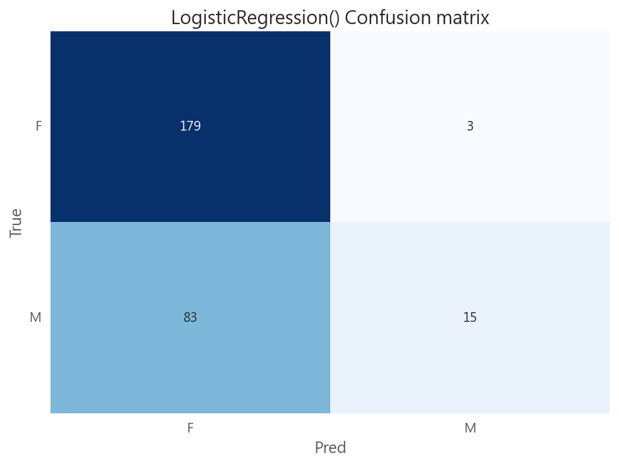

```python
result = train_cv(vectorizer, clf, X_train[mask], y_train[mask])
```

```python
print(type(dict))
```

```
<class 'dict'>
```

```
now training: clf_logistic
              precision    recall  f1-score   support

           F       0.68      0.98      0.81       182
           M       0.83      0.15      0.26        98

    accuracy                           0.69       280
   macro avg       0.76      0.57      0.53       280
weighted avg       0.74      0.69      0.61       280

====================================================================================================
now training: clf_dtree
              precision    recall  f1-score   support

           F       0.66      0.64      0.65       182
           M       0.37      0.39      0.38        98

    accuracy                           0.55       280
   macro avg       0.51      0.52      0.51       280
weighted avg       0.56      0.55      0.56       280

====================================================================================================
now training: clf_rf
              precision    recall  f1-score   support

           F       0.71      0.89      0.79       182
           M       0.62      0.34      0.44        98

    accuracy                           0.70       280
   macro avg       0.67      0.61      0.61       280
weighted avg       0.68      0.70      0.67       280
```

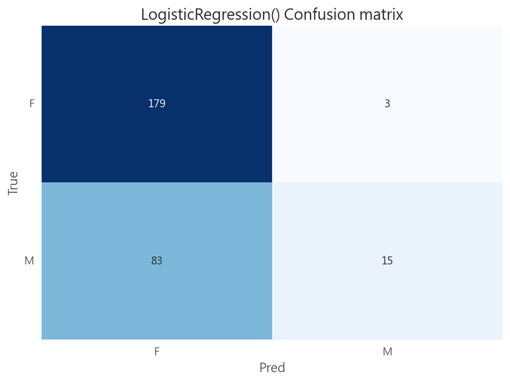

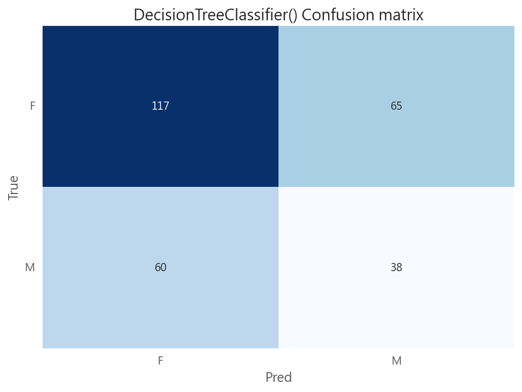

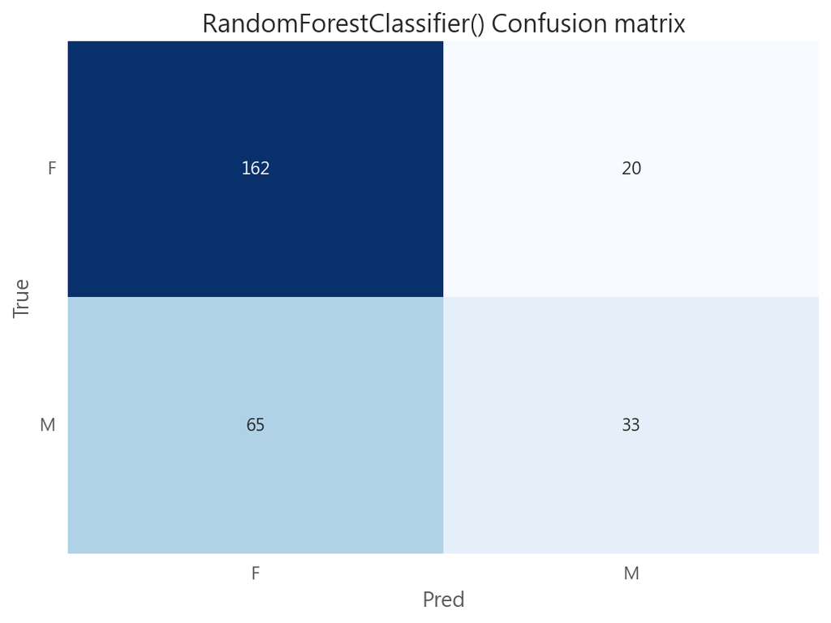

```python
# 準備訓練資料
X = data["words"]
y = data["gender"]

# 把整個資料集七三切
X_train, X_test, y_train, y_test = train_test_split(
    X, y, test_size=0.3, random_state=777
)

# 過濾掉 D 類別
X_train_filtered = X_train[mask]
y_train_filtered = y_train[mask]

# 定義模型訓練組合
model_set = {}
model_set['clf_logistic'] = LogisticRegression()
model_set['clf_dtree'] = DecisionTreeClassifier()
model_set['clf_rf'] = RandomForestClassifier()
vectorizer = TfidfVectorizer(max_features=1000)
result_set = {}

for k, model in model_set.items():
    print("="*100)
    print(f"now training: {k}")
    result_set[k] = train_cv(vectorizer, model, X_train_filtered, y_train_filtered)
```

找出f1-score表現最好的模型是哪個，作為我們最終得到的分類器

```python
max = 0
best_model_name = ""
best_model_metric = "f1-score"

## choose max f1-score model from result_set
for k, v in result_set.items():
    if v['weighted avg'][best_model_metric] > max:
        max = v['weighted avg'][best_model_metric]
        best_model_name = k
print(f"best model: {best_model_name}")
pprint(result_set[best_model_name])
```

```
best model: clf_rf
{'F': {'f1-score': 0.7921760391198044,
       'precision': 0.7136563876651982,
       'recall': 0.8901098901098901,
       'support': 182.0},
 'M': {'f1-score': 0.4370860927152318,
       'precision': 0.6226415094339622,
       'recall': 0.336734693877551,
       'support': 98.0},
 'accuracy': 0.6964285714285714,
 'macro avg': {'f1-score': 0.614631065917518,
               'precision': 0.6681489485495802,
               'recall': 0.6134222919937206,
               'support': 280.0},
 'weighted avg': {'f1-score': 0.667894557878204,
                  'precision': 0.6818011802842657,
                  'recall': 0.6964285714285714,
                  'support': 280.0}}
```

```python
y_pred = model_set['clf_rf'].predict(vectorizer.transform(X_test).toarray())
print(classification_report(y_test, y_pred))
```

```
              precision    recall  f1-score   support

           F       0.69      0.88      0.77       173
           M       0.62      0.34      0.44       104

    accuracy                           0.68       277
   macro avg       0.66      0.61      0.60       277
weighted avg       0.66      0.68      0.65       277
```

```python
model_set['clf_rf'].predict(vectorizer.transform(["I人 喜歡 安靜 不擅長 社交 社恐 安全感 追求 他們 技巧 避免 行為"]).toarray())
```

```
array(['F'], dtype=object)
```

- 最佳的 model 為 Random Forest，其餘2個 model （Logistic、Decision Tree）表現差不多。

## 分析可解釋模型的結果

對於線性的模型，可以藉由相關係數，查看資料特徵（詞）對於判斷分類的影響

```python
import pandas as pd
import numpy as np
import matplotlib.pyplot as plt

def plot_coef(logistic_reg_model, feature_names, top_n=10):
    # 選出前10大影響力詞彙
    log_odds = logistic_reg_model.coef_[0]  # 取出單一類別的係數 (1000,)
    # 創建 DataFrame，包含兩個類別：正係數對應 M，負係數對應 F
    coef_df = pd.DataFrame({
        'M': log_odds,           # 正係數表示 M 的影響
        'F': -log_odds           # 負係數表示 F 的影響
    }, index=feature_names)

    for label in coef_df.columns:
        select_words = (
            coef_df[[label]]
            .sort_values(by=label, ascending=False)
            .iloc[np.r_[0:top_n, -top_n:0]]
        )
        word = select_words.index
        count = select_words[label]
        category_colors = np.where(
            select_words[label] >= 0, "darkseagreen", "rosybrown"
        )

        fig, ax = plt.subplots(figsize=(8, top_n*0.8))
        plt.rcParams["axes.unicode_minus"] = False

        ax.barh(word, count, color=category_colors)
        ax.invert_yaxis()
        ax.set_title(
            f"Coeff increase/decrease odds ratio of '{label}' label the most",
            loc="left",
            size=16,
        )
        ax.set_ylabel("word", size=14)
        ax.set_xlabel("odds ratio", size=14)
        plt.show()
```

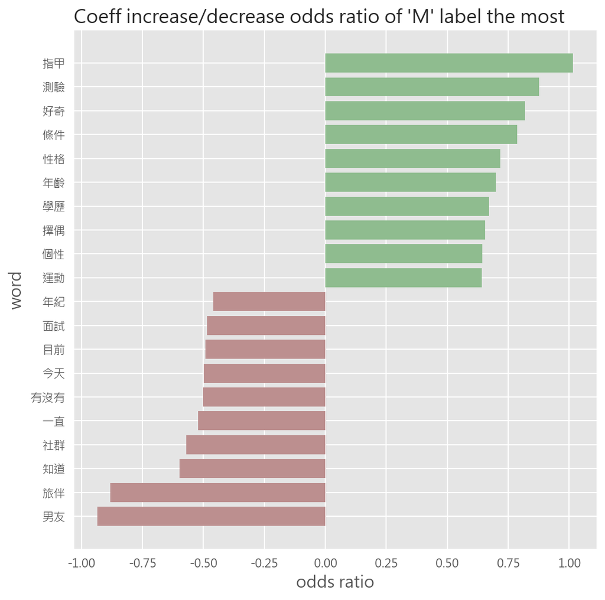

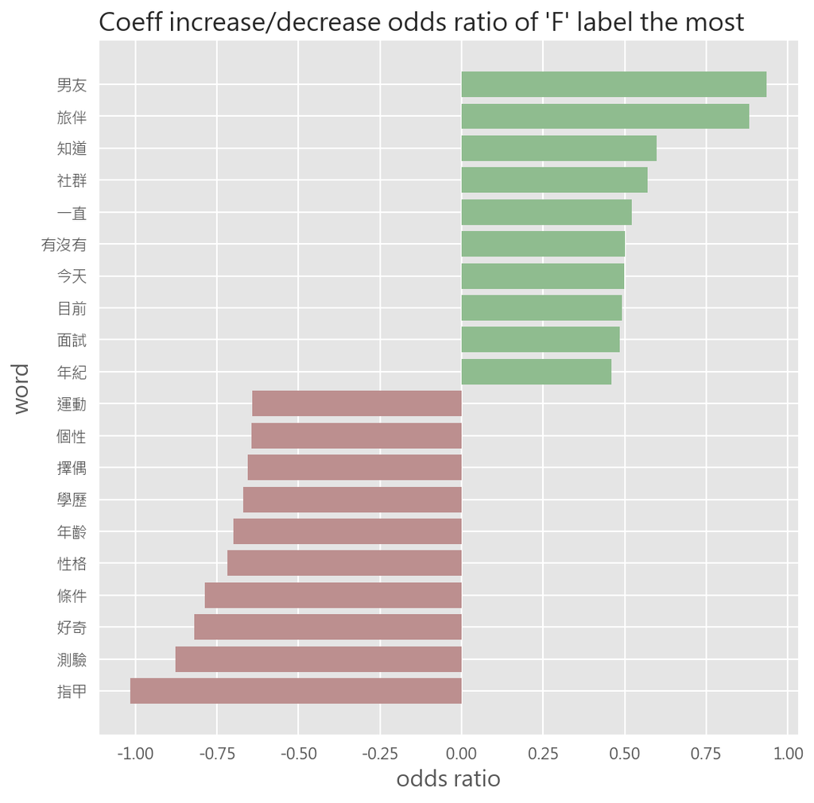

```python
plot_coef(logistic_reg_model=model_set['clf_logistic'], feature_names=vectorizer.get_feature_names_out(), top_n=10)
```

## 主題模型

1. LDA 主題模型
2. 視覺化主題模型

```python
from functools import reduce
from collections import Counter
from pprint import pprint

from sklearn.feature_extraction.text import TfidfVectorizer, CountVectorizer
from gensim.corpora import Dictionary
from gensim.models import LdaModel, CoherenceModel
from gensim.models.ldamulticore import LdaMulticore
from gensim.matutils import corpus2csc, corpus2dense, Sparse2Corpus

import pyLDAvis
import pyLDAvis.gensim_models
```

```python
MBTI_FM["words"] = MBTI_FM["content"].apply(getToken)
MBTI_FM['gender'].unique()
MBTI_FM.head()
```

|  | content | artUrl | gender | words |
| --- | --- | --- | --- | --- |
| 0 | 為什麼人可以用來當作不社交的藉口如題，現在很紅，但我很不解有些人常常碰到需要溝通的事情就說自... | https://www.dcard.tw/f/talk/p/257640963 | M | [用來, 當作, 社交, 藉口, 現在, 很紅, 不解, 碰到, 需要, 溝通, 事情, 東... |
| 1 | 這麼剛好！我和她的相遇，在盛夏。而偏偏，這個夏，颱風特別多，所以緣分恰似撞在了颱風眼上，悄無... | https://www.dcard.tw/f/rainbow/p/257627205 | F | [相遇, 盛夏, 颱風, 特別, 緣分, 颱風眼, 悄無聲息, 襯著, 神秘, 難覺, 往後... |
| 2 | 不回應就是不喜歡雖然知道不管是星座還是都是參考用，但不管過了多久，還是會去翻看有關於你的一切... | https://www.dcard.tw/f/mood/p/257619302 | F | [回應, 喜歡, 知道, 星座, 參考, 過了, 多久, 翻看, 知道, 想法, 早就, 知... |
| 3 | 不知道姐姐對我有沒有好感在迪卡上認識了一個姐姐到今天已經連續聊一個禮拜因為我想說慢慢來所以聊... | https://www.dcard.tw/f/rainbow/p/257635779 | F | [知道, 姐姐, 有沒有, 好感, 迪卡上, 認識, 姐姐, 今天, 已經, 連續, 禮拜,... |
| 4 | 不去要就很膽小？？？今天剛好悠閒來測然後，我測試出來的是，我就把這個測試結果放在便利貼裡面，... | https://www.dcard.tw/f/mood/p/257603606 | F | [不去, 膽小, 今天, 悠閒, 來測, 測試, 測試, 放在, 便利, 貼裡面, 晚上, ... |

## LDA 主題模型

```python
# 將每個字串分詞為列表
docs = MBTI_FM['words'].to_list()
docs[0]
```

```
['用來',
 '當作',
 '社交',
 '藉口',
 '現在',
 '很紅',
 '不解',
 '碰到',
 '需要',
 '溝通',
 '事情',
 '東西',
 '丟給',
 '其他人',
 '處理',
 '心態',
 '大學',
 '剛出',
 '社會',
 '客戶',
 '半個',
 '見到',
 '陌生人',
 '尷尬',
 '取經',
 '影片',
 '上課',
 '學習',
 '溝通',
 '方式',
 '至少',
 '內向',
 '懼怕',
 '陌生人',
 '交談',
 '溝通',
 '冷掉',
 '現在',
 '現在',
 '變得',
 '喜歡',
 '社交',
 '喜歡',
 '覺得',
 '感覺',
 '限制',
 '生活',
 '工作',
 '有用',
 '事情',
 '喜歡',
 '不學',
 '每次',
 '聽到',
 '內向',
 '社交',
 '事給',
 '處理',
 '好心',
 '裡就']
```

建立並過濾詞彙表（dictionary），只保留特定條件的詞彙

```python
dictionary = Dictionary(docs)

dictionary.filter_extremes(no_below=5, no_above=0.99)
print(dictionary)
```

```
Dictionary<3850 unique tokens: ['上課', '不解', '丟給', '事情', '交談']...>
```

參數說明：

- no_below=5 出現在少於 5 篇文章中的詞會被移除
- no_above=0.99 出現在超過 99% 文件中的詞會被移除

```python
for idx, (k, v) in enumerate(dictionary.token2id.items()):
    print(f"{k}: {v}")
    if idx > 10:
        break
```

```
上課: 0
不解: 1
丟給: 2
事情: 3
交談: 4
內向: 5
其他人: 6
冷掉: 7
半個: 8
喜歡: 9
大學: 10
學習: 11
```

將斷詞結果建構語料庫(corpus)之後，利用語料庫把每篇文章數字化。  
每個詞彙都被賦予一個 ID 及頻率(word_id，word_frequency)。

```python
pprint(" ".join(MBTI_FM['words'].iloc[600]))
```

```
('閒聊 寧寧 討論 社群 新創 寧寧 討論 社群 希望 台灣 同樣 喜歡 寧寧 一起 討論 共享 資訊 歡迎 加入 密碼 提示 寧寧 代表 動物 邀請 '
 '加入 寧藝卓 粉絲 點選 以下 連結 加入 社群')
```

第600篇文章的前十個詞彙的語料庫ID和頻率

```python
dictionary.doc2bow(MBTI_FM['words'].iloc[600])[:10]
```

```
[(9, 1),
 (173, 1),
 (195, 1),
 (212, 1),
 (234, 1),
 (275, 1),
 (428, 1),
 (660, 1),
 (791, 1),
 (925, 3)]
```

#### 將docs轉換成BOW形式

- 把每篇文件的 token list 轉換成一組 (token_id, count) 的 list

```python
# 建立 Bag-of-words 作為文章的特徵表示
# 用 gensim ldamodel input 需要將文章轉換成 bag of words
corpus = [dictionary.doc2bow(doc) for doc in docs]
```

### 開始訓練 LDA topic model

- 參數說明：
  - corpus = 文檔語料庫
  - id2word = 詞彙字典
  - num_topics = 生成幾個主題數
  - random_state = 固定亂數值，每次的模型結果會一樣
  - iteration = 每個文章訓練的次數，可以設定高一點讓模型收斂
  - passes(epoch) = 整個 corpus 訓練模型的次數
  - alpha = 文章主題分佈
  - eta = 主題字分佈

模型參數沒有一個絕對的答案，同學們應該**使用相同的資料**，嘗試做參數上的調整，進而比較出較佳的模型結果。

```python
ldamodel = LdaModel(
    corpus=corpus,
    id2word=dictionary, # 字典
    num_topics=10, # 生成幾個主題數
    random_state=2024, # 亂數
)
```

### 查看 LDA 主題代表字

當 LDA 模型訓練好之後，我們可以查看每個主題的單詞分佈。  
num_words = 選擇要查看每個主題前幾個字。

```python
ldamodel.print_topics()
```

```
[(0,
  '0.011*"喜歡" + 0.011*"覺得" + 0.011*"一起" + 0.008*"朋友" + 0.007*"知道" + 0.007*"女生" + 0.006*"感覺" + 0.006*"真的" + 0.006*"比較" + 0.006*"對方"'),
 (1,
  '0.014*"覺得" + 0.013*"朋友" + 0.011*"喜歡" + 0.009*"知道" + 0.009*"真的" + 0.006*"分享" + 0.006*"一起" + 0.006*"對方" + 0.006*"認識" + 0.005*"工作"'),
 (2,
  '0.016*"真的" + 0.013*"喜歡" + 0.007*"知道" + 0.007*"覺得" + 0.007*"朋友" + 0.006*"時間" + 0.006*"一直" + 0.005*"比較" + 0.005*"現在" + 0.004*"分享"'),
 (3,
  '0.015*"喜歡" + 0.013*"一起" + 0.011*"知道" + 0.008*"覺得" + 0.007*"女生" + 0.007*"朋友" + 0.006*"比較" + 0.006*"真的" + 0.006*"希望" + 0.005*"時間"'),
 (4,
  '0.014*"喜歡" + 0.008*"覺得" + 0.007*"對方" + 0.007*"朋友" + 0.006*"真的" + 0.006*"女生" + 0.006*"感覺" + 0.006*"比較" + 0.006*"個性" + 0.005*"知道"'),
 (5,
  '0.015*"喜歡" + 0.012*"朋友" + 0.010*"覺得" + 0.010*"希望" + 0.007*"真的" + 0.006*"工作" + 0.006*"比較" + 0.006*"一起" + 0.006*"感覺" + 0.005*"認識"'),
 (6,
  '0.010*"知道" + 0.009*"覺得" + 0.008*"真的" + 0.007*"工作" + 0.007*"一直" + 0.007*"喜歡" + 0.006*"朋友" + 0.006*"一起" + 0.005*"聊天" + 0.005*"現在"'),
 (7,
  '0.013*"真的" + 0.009*"覺得" + 0.008*"朋友" + 0.007*"工作" + 0.006*"知道" + 0.006*"看到" + 0.006*"喜歡" + 0.004*"希望" + 0.004*"一起" + 0.004*"應該"'),
 (8,
  '0.015*"覺得" + 0.011*"知道" + 0.010*"真的" + 0.007*"朋友" + 0.007*"喜歡" + 0.006*"時間" + 0.006*"一起" + 0.006*"希望" + 0.005*"一直" + 0.005*"一些"'),
 (9,
  '0.011*"覺得" + 0.009*"一起" + 0.009*"喜歡" + 0.008*"工作" + 0.007*"真的" + 0.006*"比較" + 0.005*"感覺" + 0.005*"朋友" + 0.005*"知道" + 0.005*"希望"')]
```

也可以使用 `get_document_topics()` 回去看每篇文章的主題分佈 (`theta`)

```python
ldamodel.get_document_topics(corpus[0])
```

```
[(5, 0.98332345)]
```

### 查看 LDA 模型指標

- **Pointwise Mutual Information (PMI)** :  
  自然語言處理中，想要探討兩個字之間是否存在某種關係。  
  例如：某些字會一起出現，可能帶有某些訊息，因此這個可以用 PMI 來計算，數字越大越好。
- **perplexity** :  
  perplexity 也是評估的指標之一，廣泛用於語言模型的評估，意思為複雜度，因此數字要越小越好。

```python
# perplexity
perplexity = ldamodel.log_perplexity(corpus)
perplexity
```

```
-7.917010629188171
```

將 對數 perplexity 值轉回原始的 perplexity 值

```python
np.exp2(-perplexity)
```

```
241.68943996504345
```

```python
# npmi
NPMI_model_lda = CoherenceModel(model=ldamodel, texts=docs, coherence='c_npmi')
NPMI_lda = NPMI_model_lda.get_coherence()
print('這個主題模型的 PMI score: ', NPMI_lda)
```

```
這個主題模型的 PMI score:  0.001789867582359
```

列出主題模型中，每個主題詞語之間的PMI score

```python
NPMI_model_lda.get_coherence_per_topic()
```

```
[0.0014957363349474863,
 -0.0033873107679616276,
 -0.006691701190211496,
 0.0075562679225820994,
 0.013779983147706502,
 -0.0022098827880109176,
 0.008753840046324011,
 -0.0037737606943235922,
 -0.0020087037135305685,
 0.004384207526068102]
```

`NPMI` 的值域是[-1,1]，-1 代表兩個字沒一起出現過，0 代表兩個字之間獨立，1 代表兩個字完全相關

### 透過指標找出最佳主題數

**再次強調**：主題數及參數沒有一個絕對正確的答案，同學們應該**使用相同的資料**，嘗試做參數上的調整、主題數的調整，進而比較出較佳的模型結果。

```python
t0 = time.time()

topic_num_list = np.arange(2, 10)
result = {"topic_num":[], "perplexity":[], "pmi":[]}
model_set = { }


for topic_num in topic_num_list:
    # perplexity
    model = LdaModel(
        corpus = corpus,
        num_topics = topic_num ,
        id2word=dictionary,
        random_state = 1500,
        passes=5 # 訓練次數
        )

    loss = model.log_perplexity(corpus)
    pmi = CoherenceModel(model=model, texts=docs, coherence='c_npmi').get_coherence()
    perplexity = np.exp(-1. * loss)

    # model_set[f'k_{topic_num}'] = model

    result['topic_num'].append(topic_num)
    result['perplexity'].append(perplexity)
    result['pmi'].append(pmi)

print(f"花費時間: {time.time() - t0} sec")
```

```
花費時間: 100.17699694633484 sec
```

```python
result = pd.DataFrame(result)
result
```

|  | topic_num | perplexity | pmi |
| --- | --- | --- | --- |
| 0 | 2 | 1758.350629 | -0.000885 |
| 1 | 3 | 1751.005793 | -0.028242 |
| 2 | 4 | 1693.005899 | -0.017742 |
| 3 | 5 | 1713.542010 | -0.017100 |
| 4 | 6 | 1731.801039 | -0.003609 |
| 5 | 7 | 1770.302690 | 0.004210 |
| 6 | 8 | 1823.027819 | 0.008801 |
| 7 | 9 | 1856.900302 | -0.002201 |

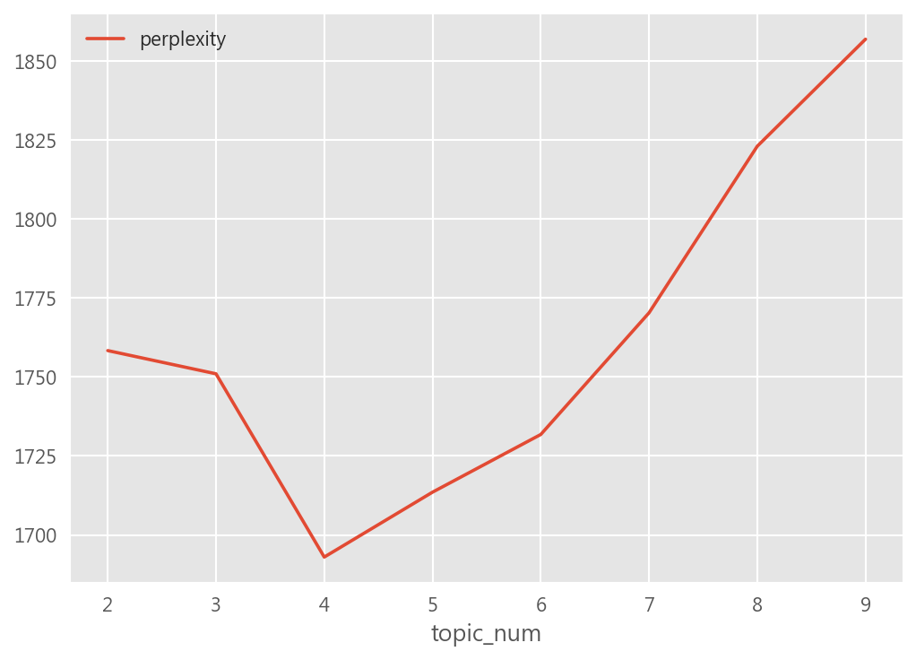

```python
result.plot.line(x='topic_num', y='perplexity')
```

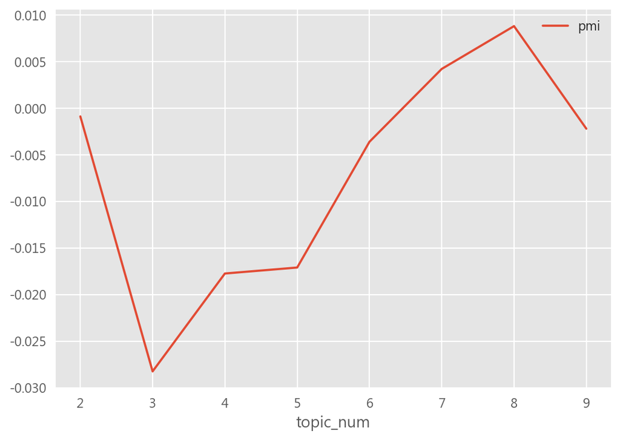

```python
result.plot.line(x='topic_num', y='pmi')
```

## 視覺化呈現

LDAvis 是我們經常會使用的視覺化工具，目的為幫助我們解釋主題模型中，在我們建構好主題模型得到 θ(文件的主題分佈) 跟 φ(主題的字分佈)，透過 pyLDAvis 將主題降維成二維，以網頁的形式供我們查看。

- 圓圈數量代表主題數量，有幾個主題就會有幾個圓圈
- 圓越大代表 document 越大
- 右邊可以看到主題的字分佈
- 右上幫有一個 bar 調整 lambda：當 lambda=1 也就是代表本來的字分佈 φ，將 lambda 縮越小可以看到越唯一的字，好的分佈是 φ 高且唯一，因此我們要在這兩者間取平衡
- 圓心越相近，代表主題會越相似；反之，圓心分越開代表主題有唯一性  
  --> 假設詞彙本來有 100 字，維度應該是 100，假如本來維度接近(相近)的話，降維後也會接近(相近)

以下用主題數 8 來做 LDAvis 的結果範例

```python
best_model = LdaModel(
    corpus = corpus,
    num_topics = 8,
    id2word=dictionary,
    random_state = 1500,
    passes = 5 # 訓練次數
    )
```

```python
pyLDAvis.enable_notebook()
p = pyLDAvis.gensim_models.prepare(best_model, corpus, dictionary)
p
```

[interactive chart not shown]

可以看到(1,7)、(2,3)和(3,4)很相近，試試看跑5個主題

```python
model_5 = LdaModel(
    corpus = corpus,
    num_topics = 5,
    id2word=dictionary,
    random_state = 1500,
    passes = 5 # 訓練次數
    )
pyLDAvis.enable_notebook()
p = pyLDAvis.gensim_models.prepare(model_5, corpus, dictionary)
p
```

[interactive chart not shown]